# coordinated_ordering12

GroupB

06/08/2020

# Data preparation

$Total_racks=8$, $levels_per_rack=4$, $rack_length= 6000$, $rack_width=1750$, $rack_height=300$

```r
library(readxl)

product_data <- read_excel("Data_ordering.xlsx",sheet = "product data")
box_data <- read_excel("Data_ordering.xlsx",sheet = "box data")
#rack data
Total_racks=8
levels_per_rack=4
rack_length= 6000
rack_width=1750
rack_height=300

init<- data.frame(Total_racks,levels_per_rack,rack_length,rack_width,rack_height)
colnames(init)<- c("Total_racks","levels_per_rack","rack_length","rack_width","rack_height")
rownames(init)<-"Rack Information"
kable(init,digits = c(1,1,1,1,1), caption= "Storage Information", format= "pandoc")
```

Storage Information

|  | Total_racks | levels_per_rack | rack_length | rack_width | rack_height |
| --- | --- | --- | --- | --- | --- |
| Rack Information | 8 | 4 | 6000 | 1750 | 300 |

```r
#product_data
product_data<-cbind(1:62,product_data)
colnames(product_data)<- c("N0", "material ID","demand per day","box ID","pieces/box","price")

kable(product_data,format = "pandoc")
```

| N0 | material ID | demand per day | box ID | pieces/box | price |
| --- | --- | --- | --- | --- | --- |
| 1 | 7305667+74 | 12 | 6203060 | 45 | 1.51 |
| 2 | 7305669+77 | 30 | 6203059 | 15 | 7.62 |
| 3 | 7305670+77 | 30 | 6203059 | 15 | 1.62 |
| 4 | 7305673+76 | 30 | 6203059 | 16 | 1.51 |
| 5 | 7305674+76 | 30 | 6203059 | 16 | 1.51 |
| 6 | 7305817+74 | 60 | 6203060 | 16 | 4.55 |
| 7 | 7305819+79 | 30 | 6203059 | 6 | 11.13 |
| 8 | 7305820+79 | 30 | 6203059 | 6 | 2.86 |
| 9 | 7305823+73 | 30 | 6203059 | 30 | 4.05 |
| 10 | 7305824+73 | 30 | 6203059 | 30 | 2.56 |
| 11 | 7305832+73 | 30 | 6203061 | 30 | 1.50 |
| 12 | 7305833+73 | 30 | 6203059 | 12 | 2.02 |
| 13 | 7305834+73 | 30 | 6203059 | 12 | 4.27 |
| 14 | 7305863+75 | 60 | 6203059 | 16 | 1.52 |
| 15 | 7305865+77 | 30 | 3106410 | 14 | 3.15 |
| 16 | 7305867+76 | 60 | 6203059 | 48 | 1.58 |
| 17 | 7305971+75 | 6 | 6203059 | 15 | 3.32 |
| 18 | 7305972+75 | 6 | 6203059 | 15 | 3.13 |
| 19 | 7305977+74 | 24 | 6203061 | 36 | 1.54 |
| 20 | 7306005+73 | 6 | 3108210 | 20 | 1.50 |
| 21 | 7306006+73 | 6 | 3108210 | 20 | 3.15 |
| 22 | 7306009+75 | 6 | 6203060 | 13 | 3.62 |
| 23 | 7306010+75 | 6 | 6203060 | 13 | 2.13 |
| 24 | 7306013+73 | 6 | 6203060 | 16 | 1.53 |
| 25 | 7306014+73 | 6 | 6203060 | 16 | 1.70 |
| 26 | 7306017+79 | 6 | 6203059 | 9 | 1.51 |
| 27 | 7306018+79 | 6 | 6203059 | 9 | 6.62 |
| 28 | 7306023+78 | 30 | 6203060 | 15 | 2.13 |
| 29 | 7306024+78 | 30 | 6203060 | 15 | 2.15 |
| 30 | 7306025+75 | 6 | 6203061 | 20 | 1.85 |
| 31 | 7306026+75 | 6 | 6203061 | 20 | 1.62 |
| 32 | 7306033+77 | 6 | 6203061 | 30 | 2.53 |
| 33 | 7306034+77 | 6 | 6203061 | 30 | 2.11 |
| 34 | 7306037+79 | 6 | 6203060 | 20 | 3.82 |
| 35 | 7306038+30 | 6 | 6203060 | 20 | 2.28 |
| 36 | 7308013+79 | 30 | 3108210 | 13 | 19.46 |
| 37 | 7308014+79 | 30 | 3108210 | 13 | 1.58 |
| 38 | 7313474+73 | 30 | 6203061 | 8 | 2.82 |
| 39 | 7313981+31 | 6 | 6203059 | 12 | 5.68 |
| 40 | 7313982+31 | 6 | 6203059 | 12 | 9.67 |
| 41 | 7326393+74 | 30 | 6203059 | 12 | 1.75 |
| 42 | 7326394+74 | 30 | 6203059 | 12 | 2.96 |
| 43 | 7326409+74 | 30 | 6203060 | 11 | 1.87 |
| 44 | 7326825+72 | 30 | 6203060 | 18 | 1.68 |
| 45 | 7326826+72 | 30 | 6203060 | 18 | 1.69 |
| 46 | 7328209+73 | 30 | 6203061 | 16 | 1.87 |
| 47 | 7328210+73 | 30 | 6203061 | 16 | 1.76 |
| 48 | 7332421+76 | 30 | 6203062 | 5 | 3.45 |
| 49 | 7332422+76 | 30 | 6203062 | 5 | 1.57 |
| 50 | 7343137+72 | 30 | 6203059 | 32 | 6.74 |
| 51 | 7343138+74 | 30 | 6203059 | 32 | 1.96 |
| 52 | 7346592+72 | 360 | 3103147 | 64 | 1.99 |
| 53 | 7346813+73 | 60 | 6203061 | 30 | 2.45 |
| 54 | 7348808+73 | 30 | 3103147 | 18 | 2.58 |
| 55 | 7355005+72 | 30 | 6203061 | 36 | 1.67 |
| 56 | 7355006+72 | 30 | 6203061 | 36 | 3.08 |
| 57 | 7455633+73 | 24 | 3108210 | 8 | 24.57 |
| 58 | 7455634+73 | 24 | 3108210 | 8 | 1.60 |
| 59 | 7455687+72 | 24 | 3108210 | 24 | 3.99 |
| 60 | 7455688+72 | 24 | 3108210 | 24 | 10.70 |
| 61 | 7455691+71 | 24 | 3104147 | 20 | 4.39 |
| 62 | 7455692+71 | 24 | 3104147 | 20 | 4.39 |

## Convert to Boxes

Convert demand $d_i$, quantity $q_i$ and unit price $p_i$ all from part $i$ to box $bc_i$ which is the capacity of a box for part $i$.

Demand for box with part $i$ .
$$y_i=\frac {d_i*262}{bc_i}$$

Price for box with material $i$ .
$$pr_i= bc_i \cdot p_i$$

$y_i = demand\_per\_year$

$pr_i = box\_cost=$ value of box

```r
product_data$demand_per_year= ceiling((product_data$`demand per day` *262)/ product_data$`pieces/box`)

product_data$box_cost= product_data$`pieces/box`*product_data$price

#product_data



product_data <- merge(product_data, box_data[,c("box ID", "ordering cost (€)")], by = "box ID")

colnames(product_data)[9] <- "ordering_cost"


kable(product_data,digits = c(1,1,1,1,1,1,1,1), caption= "Merged data with yearly demand", format= "pandoc")
```

Merged data with yearly demand

| box ID | N0 | material ID | demand per day | pieces/box | price | demand_per_year | box_cost | ordering_cost |
| --- | --- | --- | --- | --- | --- | --- | --- | --- |
| 3103147 | 54 | 7348808+73 | 30 | 18 | 2.6 | 437 | 46.4 | 50 |
| 3103147 | 52 | 7346592+72 | 360 | 64 | 2.0 | 1474 | 127.4 | 50 |
| 3104147 | 61 | 7455691+71 | 24 | 20 | 4.4 | 315 | 87.8 | 45 |
| 3104147 | 62 | 7455692+71 | 24 | 20 | 4.4 | 315 | 87.8 | 45 |
| 3106410 | 15 | 7305865+77 | 30 | 14 | 3.1 | 562 | 44.1 | 60 |
| 3108210 | 20 | 7306005+73 | 6 | 20 | 1.5 | 79 | 30.0 | 65 |
| 3108210 | 36 | 7308013+79 | 30 | 13 | 19.5 | 605 | 253.0 | 65 |
| 3108210 | 37 | 7308014+79 | 30 | 13 | 1.6 | 605 | 20.5 | 65 |
| 3108210 | 60 | 7455688+72 | 24 | 24 | 10.7 | 262 | 256.8 | 65 |
| 3108210 | 57 | 7455633+73 | 24 | 8 | 24.6 | 786 | 196.6 | 65 |
| 3108210 | 58 | 7455634+73 | 24 | 8 | 1.6 | 786 | 12.8 | 65 |
| 3108210 | 21 | 7306006+73 | 6 | 20 | 3.1 | 79 | 63.0 | 65 |
| 3108210 | 59 | 7455687+72 | 24 | 24 | 4.0 | 262 | 95.8 | 65 |
| 6203059 | 13 | 7305834+73 | 30 | 12 | 4.3 | 655 | 51.2 | 80 |
| 6203059 | 7 | 7305819+79 | 30 | 6 | 11.1 | 1310 | 66.8 | 80 |
| 6203059 | 3 | 7305670+77 | 30 | 15 | 1.6 | 524 | 24.3 | 80 |
| 6203059 | 4 | 7305673+76 | 30 | 16 | 1.5 | 492 | 24.2 | 80 |
| 6203059 | 14 | 7305863+75 | 60 | 16 | 1.5 | 983 | 24.3 | 80 |
| 6203059 | 2 | 7305669+77 | 30 | 15 | 7.6 | 524 | 114.3 | 80 |
| 6203059 | 50 | 7343137+72 | 30 | 32 | 6.7 | 246 | 215.7 | 80 |
| 6203059 | 8 | 7305820+79 | 30 | 6 | 2.9 | 1310 | 17.2 | 80 |
| 6203059 | 5 | 7305674+76 | 30 | 16 | 1.5 | 492 | 24.2 | 80 |
| 6203059 | 10 | 7305824+73 | 30 | 30 | 2.6 | 262 | 76.8 | 80 |
| 6203059 | 41 | 7326393+74 | 30 | 12 | 1.8 | 655 | 21.0 | 80 |
| 6203059 | 12 | 7305833+73 | 30 | 12 | 2.0 | 655 | 24.2 | 80 |
| 6203059 | 26 | 7306017+79 | 6 | 9 | 1.5 | 175 | 13.6 | 80 |
| 6203059 | 27 | 7306018+79 | 6 | 9 | 6.6 | 175 | 59.6 | 80 |
| 6203059 | 40 | 7313982+31 | 6 | 12 | 9.7 | 131 | 116.0 | 80 |
| 6203059 | 16 | 7305867+76 | 60 | 48 | 1.6 | 328 | 75.8 | 80 |
| 6203059 | 17 | 7305971+75 | 6 | 15 | 3.3 | 105 | 49.8 | 80 |
| 6203059 | 18 | 7305972+75 | 6 | 15 | 3.1 | 105 | 46.9 | 80 |
| 6203059 | 51 | 7343138+74 | 30 | 32 | 2.0 | 246 | 62.7 | 80 |
| 6203059 | 9 | 7305823+73 | 30 | 30 | 4.0 | 262 | 121.5 | 80 |
| 6203059 | 42 | 7326394+74 | 30 | 12 | 3.0 | 655 | 35.5 | 80 |
| 6203059 | 39 | 7313981+31 | 6 | 12 | 5.7 | 131 | 68.2 | 80 |
| 6203060 | 1 | 7305667+74 | 12 | 45 | 1.5 | 70 | 68.0 | 75 |
| 6203060 | 28 | 7306023+78 | 30 | 15 | 2.1 | 524 | 31.9 | 75 |
| 6203060 | 29 | 7306024+78 | 30 | 15 | 2.1 | 524 | 32.2 | 75 |
| 6203060 | 43 | 7326409+74 | 30 | 11 | 1.9 | 715 | 20.6 | 75 |
| 6203060 | 44 | 7326825+72 | 30 | 18 | 1.7 | 437 | 30.2 | 75 |
| 6203060 | 6 | 7305817+74 | 60 | 16 | 4.5 | 983 | 72.8 | 75 |
| 6203060 | 24 | 7306013+73 | 6 | 16 | 1.5 | 99 | 24.5 | 75 |
| 6203060 | 34 | 7306037+79 | 6 | 20 | 3.8 | 79 | 76.4 | 75 |
| 6203060 | 22 | 7306009+75 | 6 | 13 | 3.6 | 121 | 47.1 | 75 |
| 6203060 | 23 | 7306010+75 | 6 | 13 | 2.1 | 121 | 27.7 | 75 |
| 6203060 | 45 | 7326826+72 | 30 | 18 | 1.7 | 437 | 30.4 | 75 |
| 6203060 | 25 | 7306014+73 | 6 | 16 | 1.7 | 99 | 27.2 | 75 |
| 6203060 | 35 | 7306038+30 | 6 | 20 | 2.3 | 79 | 45.6 | 75 |
| 6203061 | 33 | 7306034+77 | 6 | 30 | 2.1 | 53 | 63.3 | 50 |
| 6203061 | 46 | 7328209+73 | 30 | 16 | 1.9 | 492 | 29.9 | 50 |
| 6203061 | 19 | 7305977+74 | 24 | 36 | 1.5 | 175 | 55.4 | 50 |
| 6203061 | 11 | 7305832+73 | 30 | 30 | 1.5 | 262 | 45.0 | 50 |
| 6203061 | 31 | 7306026+75 | 6 | 20 | 1.6 | 79 | 32.4 | 50 |
| 6203061 | 32 | 7306033+77 | 6 | 30 | 2.5 | 53 | 75.9 | 50 |
| 6203061 | 47 | 7328210+73 | 30 | 16 | 1.8 | 492 | 28.2 | 50 |
| 6203061 | 30 | 7306025+75 | 6 | 20 | 1.8 | 79 | 37.0 | 50 |
| 6203061 | 56 | 7355006+72 | 30 | 36 | 3.1 | 219 | 110.9 | 50 |
| 6203061 | 53 | 7346813+73 | 60 | 30 | 2.5 | 524 | 73.5 | 50 |
| 6203061 | 38 | 7313474+73 | 30 | 8 | 2.8 | 983 | 22.6 | 50 |
| 6203061 | 55 | 7355005+72 | 30 | 36 | 1.7 | 219 | 60.1 | 50 |
| 6203062 | 48 | 7332421+76 | 30 | 5 | 3.5 | 1572 | 17.2 | 70 |
| 6203062 | 49 | 7332422+76 | 30 | 5 | 1.6 | 1572 | 7.9 | 70 |

```r
#product_data<- product_data[,c("N0", "material ID","demand per day","box ID","pieces/box","price")]
#product_data
```

```r
product_data<- product_data[order(product_data$N0),]

row.names(product_data)<-1:62
kable(product_data,format = "pandoc")
```

| box ID | N0 | material ID | demand per day | pieces/box | price | demand_per_year | box_cost | ordering_cost |
| --- | --- | --- | --- | --- | --- | --- | --- | --- |
| 6203060 | 1 | 7305667+74 | 12 | 45 | 1.51 | 70 | 67.95 | 75 |
| 6203059 | 2 | 7305669+77 | 30 | 15 | 7.62 | 524 | 114.30 | 80 |
| 6203059 | 3 | 7305670+77 | 30 | 15 | 1.62 | 524 | 24.30 | 80 |
| 6203059 | 4 | 7305673+76 | 30 | 16 | 1.51 | 492 | 24.16 | 80 |
| 6203059 | 5 | 7305674+76 | 30 | 16 | 1.51 | 492 | 24.16 | 80 |
| 6203060 | 6 | 7305817+74 | 60 | 16 | 4.55 | 983 | 72.80 | 75 |
| 6203059 | 7 | 7305819+79 | 30 | 6 | 11.13 | 1310 | 66.78 | 80 |
| 6203059 | 8 | 7305820+79 | 30 | 6 | 2.86 | 1310 | 17.16 | 80 |
| 6203059 | 9 | 7305823+73 | 30 | 30 | 4.05 | 262 | 121.50 | 80 |
| 6203059 | 10 | 7305824+73 | 30 | 30 | 2.56 | 262 | 76.80 | 80 |
| 6203061 | 11 | 7305832+73 | 30 | 30 | 1.50 | 262 | 45.00 | 50 |
| 6203059 | 12 | 7305833+73 | 30 | 12 | 2.02 | 655 | 24.24 | 80 |
| 6203059 | 13 | 7305834+73 | 30 | 12 | 4.27 | 655 | 51.24 | 80 |
| 6203059 | 14 | 7305863+75 | 60 | 16 | 1.52 | 983 | 24.32 | 80 |
| 3106410 | 15 | 7305865+77 | 30 | 14 | 3.15 | 562 | 44.10 | 60 |
| 6203059 | 16 | 7305867+76 | 60 | 48 | 1.58 | 328 | 75.84 | 80 |
| 6203059 | 17 | 7305971+75 | 6 | 15 | 3.32 | 105 | 49.80 | 80 |
| 6203059 | 18 | 7305972+75 | 6 | 15 | 3.13 | 105 | 46.95 | 80 |
| 6203061 | 19 | 7305977+74 | 24 | 36 | 1.54 | 175 | 55.44 | 50 |
| 3108210 | 20 | 7306005+73 | 6 | 20 | 1.50 | 79 | 30.00 | 65 |
| 3108210 | 21 | 7306006+73 | 6 | 20 | 3.15 | 79 | 63.00 | 65 |
| 6203060 | 22 | 7306009+75 | 6 | 13 | 3.62 | 121 | 47.06 | 75 |
| 6203060 | 23 | 7306010+75 | 6 | 13 | 2.13 | 121 | 27.69 | 75 |
| 6203060 | 24 | 7306013+73 | 6 | 16 | 1.53 | 99 | 24.48 | 75 |
| 6203060 | 25 | 7306014+73 | 6 | 16 | 1.70 | 99 | 27.20 | 75 |
| 6203059 | 26 | 7306017+79 | 6 | 9 | 1.51 | 175 | 13.59 | 80 |
| 6203059 | 27 | 7306018+79 | 6 | 9 | 6.62 | 175 | 59.58 | 80 |
| 6203060 | 28 | 7306023+78 | 30 | 15 | 2.13 | 524 | 31.95 | 75 |
| 6203060 | 29 | 7306024+78 | 30 | 15 | 2.15 | 524 | 32.25 | 75 |
| 6203061 | 30 | 7306025+75 | 6 | 20 | 1.85 | 79 | 37.00 | 50 |
| 6203061 | 31 | 7306026+75 | 6 | 20 | 1.62 | 79 | 32.40 | 50 |
| 6203061 | 32 | 7306033+77 | 6 | 30 | 2.53 | 53 | 75.90 | 50 |
| 6203061 | 33 | 7306034+77 | 6 | 30 | 2.11 | 53 | 63.30 | 50 |
| 6203060 | 34 | 7306037+79 | 6 | 20 | 3.82 | 79 | 76.40 | 75 |
| 6203060 | 35 | 7306038+30 | 6 | 20 | 2.28 | 79 | 45.60 | 75 |
| 3108210 | 36 | 7308013+79 | 30 | 13 | 19.46 | 605 | 252.98 | 65 |
| 3108210 | 37 | 7308014+79 | 30 | 13 | 1.58 | 605 | 20.54 | 65 |
| 6203061 | 38 | 7313474+73 | 30 | 8 | 2.82 | 983 | 22.56 | 50 |
| 6203059 | 39 | 7313981+31 | 6 | 12 | 5.68 | 131 | 68.16 | 80 |
| 6203059 | 40 | 7313982+31 | 6 | 12 | 9.67 | 131 | 116.04 | 80 |
| 6203059 | 41 | 7326393+74 | 30 | 12 | 1.75 | 655 | 21.00 | 80 |
| 6203059 | 42 | 7326394+74 | 30 | 12 | 2.96 | 655 | 35.52 | 80 |
| 6203060 | 43 | 7326409+74 | 30 | 11 | 1.87 | 715 | 20.57 | 75 |
| 6203060 | 44 | 7326825+72 | 30 | 18 | 1.68 | 437 | 30.24 | 75 |
| 6203060 | 45 | 7326826+72 | 30 | 18 | 1.69 | 437 | 30.42 | 75 |
| 6203061 | 46 | 7328209+73 | 30 | 16 | 1.87 | 492 | 29.92 | 50 |
| 6203061 | 47 | 7328210+73 | 30 | 16 | 1.76 | 492 | 28.16 | 50 |
| 6203062 | 48 | 7332421+76 | 30 | 5 | 3.45 | 1572 | 17.25 | 70 |
| 6203062 | 49 | 7332422+76 | 30 | 5 | 1.57 | 1572 | 7.85 | 70 |
| 6203059 | 50 | 7343137+72 | 30 | 32 | 6.74 | 246 | 215.68 | 80 |
| 6203059 | 51 | 7343138+74 | 30 | 32 | 1.96 | 246 | 62.72 | 80 |
| 3103147 | 52 | 7346592+72 | 360 | 64 | 1.99 | 1474 | 127.36 | 50 |
| 6203061 | 53 | 7346813+73 | 60 | 30 | 2.45 | 524 | 73.50 | 50 |
| 3103147 | 54 | 7348808+73 | 30 | 18 | 2.58 | 437 | 46.44 | 50 |
| 6203061 | 55 | 7355005+72 | 30 | 36 | 1.67 | 219 | 60.12 | 50 |
| 6203061 | 56 | 7355006+72 | 30 | 36 | 3.08 | 219 | 110.88 | 50 |
| 3108210 | 57 | 7455633+73 | 24 | 8 | 24.57 | 786 | 196.56 | 65 |
| 3108210 | 58 | 7455634+73 | 24 | 8 | 1.60 | 786 | 12.80 | 65 |
| 3108210 | 59 | 7455687+72 | 24 | 24 | 3.99 | 262 | 95.76 | 65 |
| 3108210 | 60 | 7455688+72 | 24 | 24 | 10.70 | 262 | 256.80 | 65 |
| 3104147 | 61 | 7455691+71 | 24 | 20 | 4.39 | 315 | 87.80 | 45 |
| 3104147 | 62 | 7455692+71 | 24 | 20 | 4.39 | 315 | 87.80 | 45 |

```r
product_data
```

|  | box ID | N0 | material ID | demand per day | pieces/box | price | demand_per_year | box_cost | ordering_cost |
| --- | --- | --- | --- | --- | --- | --- | --- | --- | --- |
| 1 | 6203060 | 1 | 7305667+74 | 12 | 45 | 1.51 | 70 | 67.95 | 75 |
| 2 | 6203059 | 2 | 7305669+77 | 30 | 15 | 7.62 | 524 | 114.30 | 80 |
| 3 | 6203059 | 3 | 7305670+77 | 30 | 15 | 1.62 | 524 | 24.30 | 80 |
| 4 | 6203059 | 4 | 7305673+76 | 30 | 16 | 1.51 | 492 | 24.16 | 80 |
| 5 | 6203059 | 5 | 7305674+76 | 30 | 16 | 1.51 | 492 | 24.16 | 80 |
| 6 | 6203060 | 6 | 7305817+74 | 60 | 16 | 4.55 | 983 | 72.80 | 75 |
| 7 | 6203059 | 7 | 7305819+79 | 30 | 6 | 11.13 | 1310 | 66.78 | 80 |
| 8 | 6203059 | 8 | 7305820+79 | 30 | 6 | 2.86 | 1310 | 17.16 | 80 |
| 9 | 6203059 | 9 | 7305823+73 | 30 | 30 | 4.05 | 262 | 121.50 | 80 |
| 10 | 6203059 | 10 | 7305824+73 | 30 | 30 | 2.56 | 262 | 76.80 | 80 |

[output cut: 52 more lines]

# Separate Ordering (SO)

$c_i^{or}=$ ordering cost for part $i$

$c_i^{sh}=$ stock holding cost rate based on unit price $p_i$ and interest rate $h, \qquad$ therefore $c_i^{sh}=pr_i \cdot h$

## EOQ modelling

calculate EOQ for each part i:

$$q_i^{max} = \sqrt \frac{2 \cdot y_i \cdot (c_i^{or}+c^{-or})}{pr_i \cdot h}$$

Min EOQ, used in starting feasible solution.

$$q_i^{min} = \sqrt \frac{2 \cdot y_i \cdot (c_i^{or})} {pr_i \cdot h}$$
$q_i^{max}== q^*$ these notations can be used interchangably both meaning Maximum EOQ.

```r
#dei= demand_per_year, cori= ordering cost for box i
#cord= ordering cost, pri= box cost, h= interest rate

# directly vectorized
so_eoq_fun <- Vectorize(function(dei,cori,cord,pri,h){
  eoq<- sqrt((2*dei*(cori+cord))/(pri*h))
  return(eoq)
})

# maximum EOQ provided there is no coordination of ordering cycles (i.e., cord are not shared among parallely ordered items)
vec_so_eoq_fun.max <- so_eoq_fun(dei = product_data$demand_per_year,cori=product_data$ordering_cost,cord=1500,pri=product_data$box_cost,h=0.10)
# minimum EOQ disregarding common ordering cost cord
vec_so_eoq_fun.min <- so_eoq_fun(dei = product_data$demand_per_year,cori=product_data$ordering_cost,cord=0,pri=product_data$box_cost,h=0.10)

product_data$eoq.min <- round(vec_so_eoq_fun.min)
product_data$eoq.max <- round(vec_so_eoq_fun.max)
#product_data

kable(product_data,digits = c(1,1,1,1,1,1,1,1), caption= "Both EOQs added to the table", format= "pandoc")
```

Both EOQs added to the table

| box ID | N0 | material ID | demand per day | pieces/box | price | demand_per_year | box_cost | ordering_cost | eoq.min | eoq.max |
| --- | --- | --- | --- | --- | --- | --- | --- | --- | --- | --- |
| 6203060 | 1 | 7305667+74 | 12 | 45 | 1.5 | 70 | 68.0 | 75 | 39 | 180 |
| 6203059 | 2 | 7305669+77 | 30 | 15 | 7.6 | 524 | 114.3 | 80 | 86 | 381 |
| 6203059 | 3 | 7305670+77 | 30 | 15 | 1.6 | 524 | 24.3 | 80 | 186 | 825 |
| 6203059 | 4 | 7305673+76 | 30 | 16 | 1.5 | 492 | 24.2 | 80 | 181 | 802 |
| 6203059 | 5 | 7305674+76 | 30 | 16 | 1.5 | 492 | 24.2 | 80 | 181 | 802 |
| 6203060 | 6 | 7305817+74 | 60 | 16 | 4.5 | 983 | 72.8 | 75 | 142 | 652 |
| 6203059 | 7 | 7305819+79 | 30 | 6 | 11.1 | 1310 | 66.8 | 80 | 177 | 787 |
| 6203059 | 8 | 7305820+79 | 30 | 6 | 2.9 | 1310 | 17.2 | 80 | 349 | 1553 |
| 6203059 | 9 | 7305823+73 | 30 | 30 | 4.0 | 262 | 121.5 | 80 | 59 | 261 |
| 6203059 | 10 | 7305824+73 | 30 | 30 | 2.6 | 262 | 76.8 | 80 | 74 | 328 |
| 6203061 | 11 | 7305832+73 | 30 | 30 | 1.5 | 262 | 45.0 | 50 | 76 | 425 |
| 6203059 | 12 | 7305833+73 | 30 | 12 | 2.0 | 655 | 24.2 | 80 | 208 | 924 |
| 6203059 | 13 | 7305834+73 | 30 | 12 | 4.3 | 655 | 51.2 | 80 | 143 | 636 |
| 6203059 | 14 | 7305863+75 | 60 | 16 | 1.5 | 983 | 24.3 | 80 | 254 | 1130 |
| 3106410 | 15 | 7305865+77 | 30 | 14 | 3.1 | 562 | 44.1 | 60 | 124 | 631 |
| 6203059 | 16 | 7305867+76 | 60 | 48 | 1.6 | 328 | 75.8 | 80 | 83 | 370 |
| 6203059 | 17 | 7305971+75 | 6 | 15 | 3.3 | 105 | 49.8 | 80 | 58 | 258 |
| 6203059 | 18 | 7305972+75 | 6 | 15 | 3.1 | 105 | 46.9 | 80 | 60 | 266 |
| 6203061 | 19 | 7305977+74 | 24 | 36 | 1.5 | 175 | 55.4 | 50 | 56 | 313 |
| 3108210 | 20 | 7306005+73 | 6 | 20 | 1.5 | 79 | 30.0 | 65 | 59 | 287 |
| 3108210 | 21 | 7306006+73 | 6 | 20 | 3.1 | 79 | 63.0 | 65 | 40 | 198 |
| 6203060 | 22 | 7306009+75 | 6 | 13 | 3.6 | 121 | 47.1 | 75 | 62 | 285 |
| 6203060 | 23 | 7306010+75 | 6 | 13 | 2.1 | 121 | 27.7 | 75 | 81 | 371 |
| 6203060 | 24 | 7306013+73 | 6 | 16 | 1.5 | 99 | 24.5 | 75 | 78 | 357 |
| 6203060 | 25 | 7306014+73 | 6 | 16 | 1.7 | 99 | 27.2 | 75 | 74 | 339 |
| 6203059 | 26 | 7306017+79 | 6 | 9 | 1.5 | 175 | 13.6 | 80 | 144 | 638 |
| 6203059 | 27 | 7306018+79 | 6 | 9 | 6.6 | 175 | 59.6 | 80 | 69 | 305 |
| 6203060 | 28 | 7306023+78 | 30 | 15 | 2.1 | 524 | 31.9 | 75 | 157 | 719 |
| 6203060 | 29 | 7306024+78 | 30 | 15 | 2.1 | 524 | 32.2 | 75 | 156 | 715 |
| 6203061 | 30 | 7306025+75 | 6 | 20 | 1.8 | 79 | 37.0 | 50 | 46 | 257 |
| 6203061 | 31 | 7306026+75 | 6 | 20 | 1.6 | 79 | 32.4 | 50 | 49 | 275 |
| 6203061 | 32 | 7306033+77 | 6 | 30 | 2.5 | 53 | 75.9 | 50 | 26 | 147 |
| 6203061 | 33 | 7306034+77 | 6 | 30 | 2.1 | 53 | 63.3 | 50 | 29 | 161 |
| 6203060 | 34 | 7306037+79 | 6 | 20 | 3.8 | 79 | 76.4 | 75 | 39 | 180 |
| 6203060 | 35 | 7306038+30 | 6 | 20 | 2.3 | 79 | 45.6 | 75 | 51 | 234 |
| 3108210 | 36 | 7308013+79 | 30 | 13 | 19.5 | 605 | 253.0 | 65 | 56 | 274 |
| 3108210 | 37 | 7308014+79 | 30 | 13 | 1.6 | 605 | 20.5 | 65 | 196 | 960 |
| 6203061 | 38 | 7313474+73 | 30 | 8 | 2.8 | 983 | 22.6 | 50 | 209 | 1162 |
| 6203059 | 39 | 7313981+31 | 6 | 12 | 5.7 | 131 | 68.2 | 80 | 55 | 246 |
| 6203059 | 40 | 7313982+31 | 6 | 12 | 9.7 | 131 | 116.0 | 80 | 43 | 189 |
| 6203059 | 41 | 7326393+74 | 30 | 12 | 1.8 | 655 | 21.0 | 80 | 223 | 993 |
| 6203059 | 42 | 7326394+74 | 30 | 12 | 3.0 | 655 | 35.5 | 80 | 172 | 763 |
| 6203060 | 43 | 7326409+74 | 30 | 11 | 1.9 | 715 | 20.6 | 75 | 228 | 1046 |
| 6203060 | 44 | 7326825+72 | 30 | 18 | 1.7 | 437 | 30.2 | 75 | 147 | 675 |
| 6203060 | 45 | 7326826+72 | 30 | 18 | 1.7 | 437 | 30.4 | 75 | 147 | 673 |
| 6203061 | 46 | 7328209+73 | 30 | 16 | 1.9 | 492 | 29.9 | 50 | 128 | 714 |
| 6203061 | 47 | 7328210+73 | 30 | 16 | 1.8 | 492 | 28.2 | 50 | 132 | 736 |
| 6203062 | 48 | 7332421+76 | 30 | 5 | 3.5 | 1572 | 17.2 | 70 | 357 | 1692 |
| 6203062 | 49 | 7332422+76 | 30 | 5 | 1.6 | 1572 | 7.9 | 70 | 529 | 2508 |
| 6203059 | 50 | 7343137+72 | 30 | 32 | 6.7 | 246 | 215.7 | 80 | 43 | 190 |
| 6203059 | 51 | 7343138+74 | 30 | 32 | 2.0 | 246 | 62.7 | 80 | 79 | 352 |
| 3103147 | 52 | 7346592+72 | 360 | 64 | 2.0 | 1474 | 127.4 | 50 | 108 | 599 |
| 6203061 | 53 | 7346813+73 | 60 | 30 | 2.5 | 524 | 73.5 | 50 | 84 | 470 |
| 3103147 | 54 | 7348808+73 | 30 | 18 | 2.6 | 437 | 46.4 | 50 | 97 | 540 |
| 6203061 | 55 | 7355005+72 | 30 | 36 | 1.7 | 219 | 60.1 | 50 | 60 | 336 |
| 6203061 | 56 | 7355006+72 | 30 | 36 | 3.1 | 219 | 110.9 | 50 | 44 | 247 |
| 3108210 | 57 | 7455633+73 | 24 | 8 | 24.6 | 786 | 196.6 | 65 | 72 | 354 |
| 3108210 | 58 | 7455634+73 | 24 | 8 | 1.6 | 786 | 12.8 | 65 | 283 | 1386 |
| 3108210 | 59 | 7455687+72 | 24 | 24 | 4.0 | 262 | 95.8 | 65 | 60 | 293 |
| 3108210 | 60 | 7455688+72 | 24 | 24 | 10.7 | 262 | 256.8 | 65 | 36 | 179 |
| 3104147 | 61 | 7455691+71 | 24 | 20 | 4.4 | 315 | 87.8 | 45 | 57 | 333 |
| 3104147 | 62 | 7455692+71 | 24 | 20 | 4.4 | 315 | 87.8 | 45 | 57 | 333 |

```r
#product_data
```

## Lane Occupation

$b_i=$ sorting column lenght or width.This determines the lane width

$b_i^{-1}=$if sorted by length then the value is width and vice versa, used for rack lenght.

Add $b_i$ and $b_i^{-1}$ to product_data table

```r
# constraints #####################################
# this can be formulated more elegantly, but it works and that suffices
b_sorting <- double(length(product_data$`box ID`))
b_not_sorting <-double(length(product_data$`box ID`))

for(j in 1: length(box_data$`box ID`)){
  for (k in 1:length(product_data$`box ID`)) {
    if(box_data$`box ID`[j]==product_data$`box ID`[k]){

      if(box_data$sorting[j]=="width"){
        b_sorting[k] <- box_data$width[j]
        b_not_sorting[k]<- box_data$length[j]

      }else{
        b_sorting[k] <- box_data$length[j]
        b_not_sorting[k]<- box_data$width[j]
      }
    }
  }

}

product_data$b_sorting <- b_sorting
product_data$b_not_sorting <- b_not_sorting
#product_data

kable(product_data,digits = c(1,1,1,1,1,1,1,1), caption= "Both EOQs added to the table", format= "pandoc")
```

Both EOQs added to the table

| box ID | N0 | material ID | demand per day | pieces/box | price | demand_per_year | box_cost | ordering_cost | eoq.min | eoq.max | b_sorting | b_not_sorting |
| --- | --- | --- | --- | --- | --- | --- | --- | --- | --- | --- | --- | --- |
| 6203060 | 1 | 7305667+74 | 12 | 45 | 1.5 | 70 | 68.0 | 75 | 39 | 180 | 396 | 297 |
| 6203059 | 2 | 7305669+77 | 30 | 15 | 7.6 | 524 | 114.3 | 80 | 86 | 381 | 594 | 396 |
| 6203059 | 3 | 7305670+77 | 30 | 15 | 1.6 | 524 | 24.3 | 80 | 186 | 825 | 594 | 396 |
| 6203059 | 4 | 7305673+76 | 30 | 16 | 1.5 | 492 | 24.2 | 80 | 181 | 802 | 594 | 396 |
| 6203059 | 5 | 7305674+76 | 30 | 16 | 1.5 | 492 | 24.2 | 80 | 181 | 802 | 594 | 396 |
| 6203060 | 6 | 7305817+74 | 60 | 16 | 4.5 | 983 | 72.8 | 75 | 142 | 652 | 396 | 297 |
| 6203059 | 7 | 7305819+79 | 30 | 6 | 11.1 | 1310 | 66.8 | 80 | 177 | 787 | 594 | 396 |
| 6203059 | 8 | 7305820+79 | 30 | 6 | 2.9 | 1310 | 17.2 | 80 | 349 | 1553 | 594 | 396 |
| 6203059 | 9 | 7305823+73 | 30 | 30 | 4.0 | 262 | 121.5 | 80 | 59 | 261 | 594 | 396 |
| 6203059 | 10 | 7305824+73 | 30 | 30 | 2.6 | 262 | 76.8 | 80 | 74 | 328 | 594 | 396 |
| 6203061 | 11 | 7305832+73 | 30 | 30 | 1.5 | 262 | 45.0 | 50 | 76 | 425 | 198 | 297 |
| 6203059 | 12 | 7305833+73 | 30 | 12 | 2.0 | 655 | 24.2 | 80 | 208 | 924 | 594 | 396 |
| 6203059 | 13 | 7305834+73 | 30 | 12 | 4.3 | 655 | 51.2 | 80 | 143 | 636 | 594 | 396 |
| 6203059 | 14 | 7305863+75 | 60 | 16 | 1.5 | 983 | 24.3 | 80 | 254 | 1130 | 594 | 396 |
| 3106410 | 15 | 7305865+77 | 30 | 14 | 3.1 | 562 | 44.1 | 60 | 124 | 631 | 594 | 396 |
| 6203059 | 16 | 7305867+76 | 60 | 48 | 1.6 | 328 | 75.8 | 80 | 83 | 370 | 594 | 396 |
| 6203059 | 17 | 7305971+75 | 6 | 15 | 3.3 | 105 | 49.8 | 80 | 58 | 258 | 594 | 396 |
| 6203059 | 18 | 7305972+75 | 6 | 15 | 3.1 | 105 | 46.9 | 80 | 60 | 266 | 594 | 396 |
| 6203061 | 19 | 7305977+74 | 24 | 36 | 1.5 | 175 | 55.4 | 50 | 56 | 313 | 198 | 297 |
| 3108210 | 20 | 7306005+73 | 6 | 20 | 1.5 | 79 | 30.0 | 65 | 59 | 287 | 596 | 794 |
| 3108210 | 21 | 7306006+73 | 6 | 20 | 3.1 | 79 | 63.0 | 65 | 40 | 198 | 596 | 794 |
| 6203060 | 22 | 7306009+75 | 6 | 13 | 3.6 | 121 | 47.1 | 75 | 62 | 285 | 396 | 297 |
| 6203060 | 23 | 7306010+75 | 6 | 13 | 2.1 | 121 | 27.7 | 75 | 81 | 371 | 396 | 297 |
| 6203060 | 24 | 7306013+73 | 6 | 16 | 1.5 | 99 | 24.5 | 75 | 78 | 357 | 396 | 297 |
| 6203060 | 25 | 7306014+73 | 6 | 16 | 1.7 | 99 | 27.2 | 75 | 74 | 339 | 396 | 297 |
| 6203059 | 26 | 7306017+79 | 6 | 9 | 1.5 | 175 | 13.6 | 80 | 144 | 638 | 594 | 396 |
| 6203059 | 27 | 7306018+79 | 6 | 9 | 6.6 | 175 | 59.6 | 80 | 69 | 305 | 594 | 396 |
| 6203060 | 28 | 7306023+78 | 30 | 15 | 2.1 | 524 | 31.9 | 75 | 157 | 719 | 396 | 297 |
| 6203060 | 29 | 7306024+78 | 30 | 15 | 2.1 | 524 | 32.2 | 75 | 156 | 715 | 396 | 297 |
| 6203061 | 30 | 7306025+75 | 6 | 20 | 1.8 | 79 | 37.0 | 50 | 46 | 257 | 198 | 297 |
| 6203061 | 31 | 7306026+75 | 6 | 20 | 1.6 | 79 | 32.4 | 50 | 49 | 275 | 198 | 297 |
| 6203061 | 32 | 7306033+77 | 6 | 30 | 2.5 | 53 | 75.9 | 50 | 26 | 147 | 198 | 297 |
| 6203061 | 33 | 7306034+77 | 6 | 30 | 2.1 | 53 | 63.3 | 50 | 29 | 161 | 198 | 297 |
| 6203060 | 34 | 7306037+79 | 6 | 20 | 3.8 | 79 | 76.4 | 75 | 39 | 180 | 396 | 297 |
| 6203060 | 35 | 7306038+30 | 6 | 20 | 2.3 | 79 | 45.6 | 75 | 51 | 234 | 396 | 297 |
| 3108210 | 36 | 7308013+79 | 30 | 13 | 19.5 | 605 | 253.0 | 65 | 56 | 274 | 596 | 794 |
| 3108210 | 37 | 7308014+79 | 30 | 13 | 1.6 | 605 | 20.5 | 65 | 196 | 960 | 596 | 794 |
| 6203061 | 38 | 7313474+73 | 30 | 8 | 2.8 | 983 | 22.6 | 50 | 209 | 1162 | 198 | 297 |
| 6203059 | 39 | 7313981+31 | 6 | 12 | 5.7 | 131 | 68.2 | 80 | 55 | 246 | 594 | 396 |
| 6203059 | 40 | 7313982+31 | 6 | 12 | 9.7 | 131 | 116.0 | 80 | 43 | 189 | 594 | 396 |
| 6203059 | 41 | 7326393+74 | 30 | 12 | 1.8 | 655 | 21.0 | 80 | 223 | 993 | 594 | 396 |
| 6203059 | 42 | 7326394+74 | 30 | 12 | 3.0 | 655 | 35.5 | 80 | 172 | 763 | 594 | 396 |
| 6203060 | 43 | 7326409+74 | 30 | 11 | 1.9 | 715 | 20.6 | 75 | 228 | 1046 | 396 | 297 |
| 6203060 | 44 | 7326825+72 | 30 | 18 | 1.7 | 437 | 30.2 | 75 | 147 | 675 | 396 | 297 |
| 6203060 | 45 | 7326826+72 | 30 | 18 | 1.7 | 437 | 30.4 | 75 | 147 | 673 | 396 | 297 |
| 6203061 | 46 | 7328209+73 | 30 | 16 | 1.9 | 492 | 29.9 | 50 | 128 | 714 | 198 | 297 |
| 6203061 | 47 | 7328210+73 | 30 | 16 | 1.8 | 492 | 28.2 | 50 | 132 | 736 | 198 | 297 |
| 6203062 | 48 | 7332421+76 | 30 | 5 | 3.5 | 1572 | 17.2 | 70 | 357 | 1692 | 594 | 396 |
| 6203062 | 49 | 7332422+76 | 30 | 5 | 1.6 | 1572 | 7.9 | 70 | 529 | 2508 | 594 | 396 |
| 6203059 | 50 | 7343137+72 | 30 | 32 | 6.7 | 246 | 215.7 | 80 | 43 | 190 | 594 | 396 |
| 6203059 | 51 | 7343138+74 | 30 | 32 | 2.0 | 246 | 62.7 | 80 | 79 | 352 | 594 | 396 |
| 3103147 | 52 | 7346592+72 | 360 | 64 | 2.0 | 1474 | 127.4 | 50 | 108 | 599 | 198 | 297 |
| 6203061 | 53 | 7346813+73 | 60 | 30 | 2.5 | 524 | 73.5 | 50 | 84 | 470 | 198 | 297 |
| 3103147 | 54 | 7348808+73 | 30 | 18 | 2.6 | 437 | 46.4 | 50 | 97 | 540 | 198 | 297 |
| 6203061 | 55 | 7355005+72 | 30 | 36 | 1.7 | 219 | 60.1 | 50 | 60 | 336 | 198 | 297 |
| 6203061 | 56 | 7355006+72 | 30 | 36 | 3.1 | 219 | 110.9 | 50 | 44 | 247 | 198 | 297 |
| 3108210 | 57 | 7455633+73 | 24 | 8 | 24.6 | 786 | 196.6 | 65 | 72 | 354 | 596 | 794 |
| 3108210 | 58 | 7455634+73 | 24 | 8 | 1.6 | 786 | 12.8 | 65 | 283 | 1386 | 596 | 794 |
| 3108210 | 59 | 7455687+72 | 24 | 24 | 4.0 | 262 | 95.8 | 65 | 60 | 293 | 596 | 794 |
| 3108210 | 60 | 7455688+72 | 24 | 24 | 10.7 | 262 | 256.8 | 65 | 36 | 179 | 596 | 794 |
| 3104147 | 61 | 7455691+71 | 24 | 20 | 4.4 | 315 | 87.8 | 45 | 57 | 333 | 396 | 297 |
| 3104147 | 62 | 7455692+71 | 24 | 20 | 4.4 | 315 | 87.8 | 45 | 57 | 333 | 396 | 297 |

```r
#product_data
```

E.g Using box_ID 6203060, sorted by length $b_i=396$, $b_i^{-1}=297$ Also for material ID 7305667+74 with $q_i=180$ therefore, $rack_{length}=6000$

*1.* Number of boxes in a lane:

$$n_i=\frac {rack_{length}}{b_i^{-1}}=\frac {6000}{297}=20.20=20boxes$$

*2.* How many lanes part $i$ will occupy if you order some number of boxes

$$lane_i=\frac {q_i}{n_i}$$
$$lane_i=q_i \cdot \frac {b_i^{-1}}{rack_{length}}=180 \cdot \frac {297}{6000}=8.91= 9 \space lanes$$

$$lane_i= \left\lceil\frac{b^{-1}_i \cdot q_i}{rl} \right \rceil$$

```r
lane <- ceiling(product_data$eoq.max * (product_data$b_not_sorting/rack_length))
#lane
```

3. Do we meet the capacity contraint?

*3.* Total number of lanes constraints

Collapsing Rack 4 levels in a rack and joining the 8 racks to become 1 level.

Total rack width available:

$$rack_{total_{Width}}=(rack_{width} \times 4 \times 8)$$
Note: rack_total_width which is 56,000 mm, looking at the 9 patterns all of which have 150 mm in waste, meaning all 32 levels will have 150 mm waste each. Therefor $56,000−(150∗32)=51,200$ thereby changing rack total width 51,200.

These *9 patterns* will be explained later in the chapter.

```r
rack_total_width <-51200  #rack_width * 4 * 8
#rack_total_width #56000
```

```r
lane.min <- ceiling(product_data$eoq.min * product_data$b_not_sorting / rack_length)
#lane.min
lane.max <- ceiling(product_data$eoq.max * product_data$b_not_sorting / rack_length)

#lane.max

# total rack width

rack_total_width <- 51200 # rack_width * 4 * 8

lane.df<- data.frame(rbind(lane.min,lane.max))
rownames(lane.df)<-c("Min lane","Max lane")
colnames(lane.df)<-1:62
kable(lane.df,caption = "Number of lanes that minimizes cost",format = "pandoc")
```

Number of lanes that minimizes cost

|  | 1 | 2 | 3 | 4 | 5 | 6 | 7 | 8 | 9 | 10 | 11 | 12 | 13 | 14 | 15 | 16 | 17 | 18 | 19 | 20 | 21 | 22 | 23 | 24 | 25 | 26 | 27 | 28 | 29 | … |
| --- | --- | --- | --- | --- | --- | --- | --- | --- | --- | --- | --- | --- | --- | --- | --- | --- | --- | --- | --- | --- | --- | --- | --- | --- | --- | --- | --- | --- | --- | --- |
| Min lane | 2 | 6 | 13 | 12 | 12 | 8 | 12 | 24 | 4 | 5 | 4 | 14 | 10 | 17 | 9 | 6 | 4 | 4 | 3 | 8 | 6 | 4 | 5 | 4 | 4 | 10 | 5 | 8 | 8 | … |
| Max lane | 9 | 26 | 55 | 53 | 53 | 33 | 52 | 103 | 18 | 22 | 22 | 61 | 42 | 75 | 42 | 25 | 18 | 18 | 16 | 38 | 27 | 15 | 19 | 18 | 17 | 43 | 21 | 36 | 36 | … |

```r
#product_data
```

Min lane: This lanes was derived from $q^{min}$.

Max lane: derived from $q^{max}$.

- *Overflow*

This is how much we are lacking in capacity assuming we considered optimum lanes thus optimum quatities for all our items when placing an order.

- Overflow in mm

Expressing it in mm terms

$$\Bigg[ \sum_{i=1}^n lane_i \cdot b_i \Bigg]- rack_{{total}_{width}}$$
- relative overflow in %

In percentage terms

$$\frac{\big[\sum_{i=1}^n lane_i \cdot b_i \big]- rack_{{total}_{width}}} {rack_{{total}_{width}} } \cdot 100$$

```r
# overflow in mm
overflow.mm.lane.min<- sum(lane.min*product_data$b_sorting) - rack_total_width
overflow.mm.lane.max<-sum(lane.max*product_data$b_sorting) - rack_total_width
# relative overflow in %
overflow.per.lane.min<-(sum(lane.min*product_data$b_sorting) - rack_total_width)/rack_total_width*100
overflow.per.lane.max<- (sum(lane.max*product_data$b_sorting) - rack_total_width)/rack_total_width*100

overflow<- data.frame(overflow.mm.lane.min,overflow.mm.lane.max,overflow.per.lane.min,overflow.per.lane.max)

colnames(overflow)<-c("mm_lane_min","mm_lane_max","% lane_min","% lane.max")
rownames(overflow)<- "Overflow"

kable(overflow,caption = "Rack Capacity overflow in mm and percentage",format = "pandoc")
```

Rack Capacity overflow in mm and percentage

|  | mm_lane_min | mm_lane_max | % lane_min | % lane.max |
| --- | --- | --- | --- | --- |
| Overflow | 218694 | 1173092 | 427.1367 | 2291.195 |

```r
#product_data
```

*As seen above*, the capacity is exceeded by lots of margin even without adding overall ordering capacity $c^{-or}$ it still exceeds by $427\%$

- *Introducing capacity constraint*

$$\sum_{i=1}^{n=62}lane_i \cdot b_i\le rack_{Total_{width}}$$
$$\sum_{i=1}^{n=62} q_i \cdot \frac {b_i^{-1} \cdot b_i}{rack_{length}} \le rack_{Total_{width}} \quad \quad (1)$$

```r
#get the width of the lanes in mm
rack_width_occupied=sum(lane.min*product_data$b_sorting)
kable(paste(rack_width_occupied,"mm"," is the total expected to be occupied"))
```

| x |
| --- |
| 269894 mm is the total expected to be occupied |

```r
if(rack_width_occupied <= rack_total_width){
  print(paste0("Capacity constraint fulfilled: ", rack_width_occupied, "<=",rack_total_width))

}else {
  violated <- rack_width_occupied - rack_total_width
  kable((paste0("Capacity constraint violated by: ",violated )), format = "pandoc")
}
```

| x |
| --- |
| Capacity constraint violated by: 218694 |

As seen above contraint was voilated by $218,694 mm$, thus we don’t have that kind of capacity for that, therefore we need to optimize $q_i$ to fit our capacity.

Using our example to get number of the total width i.e (summation of lanes) in $mm$: Summation of lanes can simply be:
$$lanes_i \cdot b_i= 8.91 \times 396=3528.36$$
Using equation (1) to prove this concept.

$$180 \cdot \frac {396 \cdot 297}{6000}=3528.36$$
$$b_i= \frac {3528.36}{8.91}=396$$

4. Adjust Q by reducing it:

$\frac {y_i}{q_i}=$ number of orders for part $i$.

$\frac {q_i}{2}=$ average inventory for part $i$

## Constrained EOQ optimization

$$min \rightarrow (\sum_{i=1}^{n=62}c^{-or} + \sum_{i=1}^{n=62} \frac {y_i}{q_i} \cdot c_i^{or}) + (h \cdot \sum_{i=1}^{n=62} \frac {q_i}{2}\cdot pr_i )$$
Subject to:
$$\sum_{i=1}^{n=62} q_i \cdot \frac {b_i^{-1} \cdot b_i}{rack_{length}} \le rack_{Total_{width}}$$

```r
library(ROI)
```

```r
library(ROI.plugin.alabama)

n <- length(product_data$`material ID`) #number of materials
cori <- product_data$ordering_cost   #ordering cost for each items
cord <-  1500    #ordering cost whenever there is an order
dei <- product_data$demand_per_year
h<-0.10
box_cost <- product_data$box_cost #pri

# objective function --> I dropped the 1500*62 as it is not decision relevant
obj.fun <- function(q, d= dei, c.or = cori, c.h = h*box_cost  ) (1500*62)+(sum((dei/q)*c.or)+ sum(c.h*(q/2)))
# benchmarks
#obj.fun(product_data$eoq.max)
#obj.fun(product_data$eoq.min)
# constraint function --> also contains the ceiling of lanes and a sum was missing
const.fun <- function(q, bns = product_data$b_not_sorting, bs = product_data$b_sorting, rl = rack_length) {
  sum(bs * ceiling( bns * q / rl))
  }

#const.fun(product_data$eoq.max)
#const.fun(product_data$eoq.min)
# try to figure out a freasible starting solution
#const.fun(product_data$eoq.min/10) -  rack_total_width

obj.const<- data.frame(rbind(c(obj.fun(product_data$eoq.max),const.fun(product_data$eoq.max)),c(obj.fun(product_data$eoq.min),const.fun(product_data$eoq.min) )))

colnames(obj.const)<-c("Cost Function (€)", "Capacity in (mm)")
rownames(obj.const)<-c("Eoq Max","Eoq Min")

kable(obj.const,caption = "Cost Values and capacities", format="pandoc")
```

Cost Values and capacities

[output not shown]

Now adding capacity constraint

```r
qopt <- OP(
  objective = F_objective(F=obj.fun ,n=n),
  types = rep("C",n),
  bounds = V_bound(ub= product_data$eoq.min , lb= rep(1, n)),
  constraints = F_constraint(F=const.fun,
                             dir="<=",
                             rhs = rack_total_width)
)

#This shows that minimum EOQ is too big and therefore will not meet the rack space constraint.
#const.fun(min(product_data$eoq.max))#366272
#const.fun(min(product_data$eoq.max)/8)# 61428  still > 56000
#const.fun(min(product_data$eoq.max)/8.7)#52716 < 56000
#const.fun(min(product_data$eoq.max)/10)# 33098 < 56000 is much lower but this can still be the starting value
#round(min(product_data$eoq.max)/10) #15
```

```r
copt_sol <- ROI_solve(qopt, start = rep(min(product_data$eoq.max)/10,n), solver = "alabama" )
# always check whether the algorithm converged
#copt_sol# The objective value is: 101625.9
# solution
#copt_sol$solution #vector of optimal Quantity that meets the space constraints and minimizes the Obj function.
#round(copt_sol$solution)
#copt_sol$objval #101625.9



#const.fun(copt_sol$solution)#55884
#const.fun(floor(copt_sol$solution))#55092


#obj.fun(copt_sol$solution)#101625.9
#obj.fun(floor(copt_sol$solution))#104639.7  rounded q values

copt_solution<-data.frame(obj.fun(floor(copt_sol$solution)),rbind(floor(copt_sol$solution)))
colnames(copt_solution)<-c("cost",1:62)
rownames(copt_solution)< "constrained"
```

```
## [1] TRUE
```

```r
kable(copt_solution,caption = "Capacitated values for cost and Quantity",format = "pandoc")
```

Capacitated values for cost and Quantity

| cost | 1 | 2 | 3 | 4 | 5 | 6 | 7 | 8 | 9 | 10 | 11 | 12 | 13 | 14 | 15 | 16 | 17 | 18 | 19 | 20 | 21 | 22 | 23 | 24 | 25 | 26 | 27 | 28 | 29 | … |
| --- | --- | --- | --- | --- | --- | --- | --- | --- | --- | --- | --- | --- | --- | --- | --- | --- | --- | --- | --- | --- | --- | --- | --- | --- | --- | --- | --- | --- | --- | --- |
| 205079.8 | 16 | 20 | 20 | 20 | 20 | 19 | 15 | 15 | 18 | 19 | 18 | 20 | 20 | 19 | 20 | 19 | 17 | 17 | 17 | 16 | 16 | 17 | 17 | 17 | 17 | 18 | 18 | 20 | 20 | … |

removing waste of 150 for every 32 levels

## No constraint

```r
rack_total_width <- 51200
qopt1 <- OP(
  objective = F_objective(F=obj.fun ,n=n),
  types = rep("C",n),
  bounds = V_bound(ub= product_data$eoq.min , lb= rep(1, n)),
)

copt_sol1 <- ROI_solve(qopt1, start = rep(min(product_data$eoq.max)/10,n), solver = "alabama" )
# always check whether the algorithm converged
#copt_sol1$objval
```

## Compare results

```r
obj.fun <- function(q, d= dei, c.or = cori, c.h = h*box_cost  ) (1500*62)+(sum((dei/q)*c.or)+ sum(c.h*(q/2)))
#obj.fun(product_data$eoq.max)#172279.7
```

```r
#const.fun(copt_sol$solution)#51132
#const.fun(floor(copt_sol$solution))#50340  we rounded down to avoid exceeding capacity


#obj.fun(copt_sol$solution)#109279.9
#obj.fun(floor(copt_sol$solution))#112079.8 rounded q values

const.unconst <- data.frame(rbind(c(obj.fun(floor(product_data$eoq.max)),const.fun(floor(product_data$eoq.max))),c( obj.fun(floor(copt_sol$solution)),const.fun(floor(copt_sol$solution)))))
colnames(const.unconst)<-c("Cost Function (€)","capacitaty")
rownames(const.unconst)<-c("Eoq Max","Optimized Q")

kable(const.unconst,caption = "costs",format = "pandoc")
```

costs

|  | Cost Function (€) | capacitaty |
| --- | --- | --- |
| Eoq Max | 172279.7 | 1224292 |
| Optimized Q | 205079.8 | 50340 |

```r
#obj.fun(copt_sol1$solution)#124505.1
#obj.fun(floor(copt_sol1$solution))#124508.6 rounded q values
```

Optimum costs with no capacity constraint using EOQ.max considers is €172279.7, with no capacity constraint optimized using EOQ.min is €124508.6, with capacity constraint, it costs €205079.8 This cost is expected to be higher when capacity constraint is included, as limited capacity of the rack will not allow to take advantage of cost savings.

```r
# demand vs quantity

#product_data$`demand per day`
#product_data$demand_per_year  #
```

```r
#floor(copt_sol1$solution)#  optimum quantities with no capacity constraint same as eoq.min
#floor(copt_sol$solution) # optimum quantities with capacity constraint
```

- Plot for lot sizes of costs EOQ Max vs Optimized for capacity

cost function per item
$$C(q_i) \rightarrow (c^{-or} + \frac {y_i}{q_i} \cdot c_i^{or}) + (h \cdot \frac {q_i}{2}\cdot pr_i )$$

```r
#EOQ cost

#with no constraint
#paste("with no capacity constraint, cost is  €", round(obj.fun(product_data$eoq.max)))#172280

#with no capacity constraint optimized.
#paste("with no capacity constraint optimized, cost is  €",round(obj.fun(copt_sol1$solution)))# eoq.min

#with constraint
#paste("with capacity constraint, cost is  €",round(obj.fun(copt_sol$solution))) #202280



kable(paste("It costs €",floor(obj.fun(floor(copt_sol$solution)))-floor(obj.fun(floor(product_data$eoq.max)))," extra due to lack of capacity"),format = "pandoc")
```

| x |
| --- |
| It costs € 32800 extra due to lack of capacity |

The above result shows that If there is no capacity constraint, the cost will be lower.

```r
x.val <- seq.int(1,62, length.out = 62)

cost.fun <- function(q, d= dei, c.or = cori, c.h = h*box_cost  ){
  (1500 +(dei/q)*c.or)+ (c.h*(q/2))
}

y.vec.no.const <- cost.fun(q=product_data$eoq.max)
y.vec.yes.const<- cost.fun(copt_sol$solution)

kable(paste(length(which((round(y.vec.yes.const)>=round(y.vec.no.const))==TRUE))," Items costs more or same when capacity becomes a problem"),format = "pandoc")
```

| x |
| --- |
| 26 Items costs more or same when capacity becomes a problem |

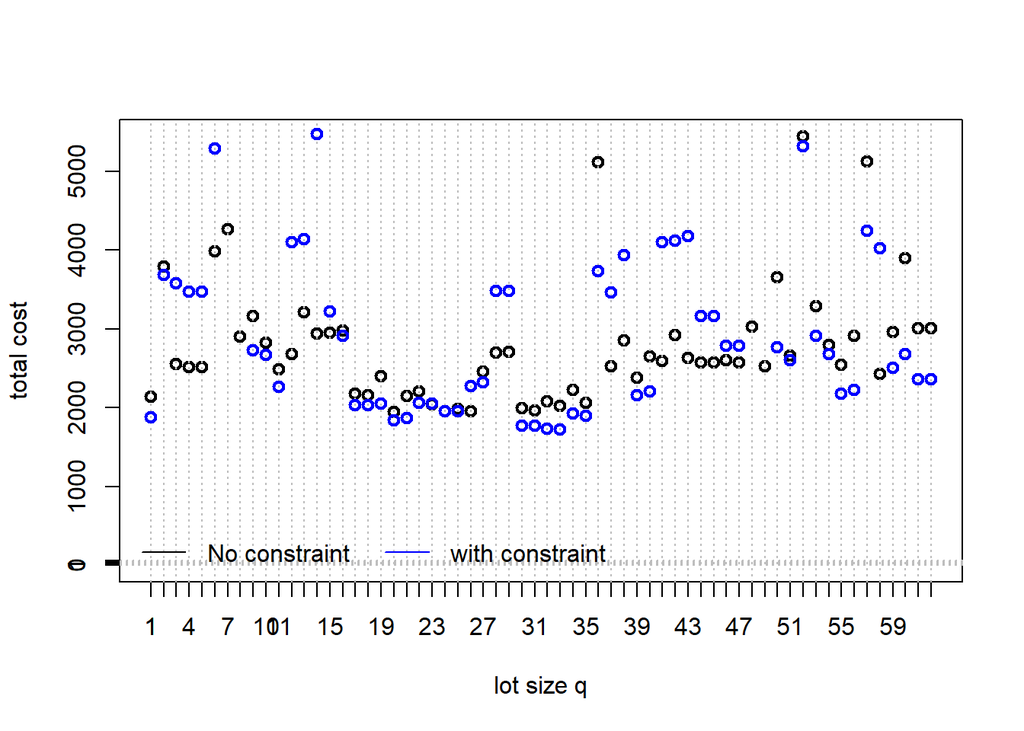

```r
#par(mfrow=c(1,1))
{
  plot(x.val,round(y.vec.no.const), xlab ="lot size q", ylab = "total cost", type = "p", lwd =2, ylim=c(12,max(y.vec.no.const)), xaxp=c(1, 10, 1) )
  axis(1, 1:62)
axis(2, 1:62)
abline(h=1:62, v=1:62, col="gray", lty=3)

points(x=x.val,y=round(y.vec.yes.const),lwd=2, col="blue")

legend("bottomleft",lty = c(1,1),col = c("black","blue"), legend = c("No constraint","with constraint"), bty="n" , horiz = T)
}
```

- Notice that 26 blue dots which represents the more expensive items when capacity is accounted for.
- Also the notice , for most items where the blue is larger than black (non constraint items)(the variance is much more) the difference is much larger. the reverse is the case when black is larger than blue.

# Joint Ordering (JO)

Using Joint replenishment problem

Assumptions:

- One supplier with outbound storage.
- $i=\{1,...,n\}$ products
- Demand rates: $de_i$
- Stock_holding cost rates: $c_i^{sh}$
- Specific setup costs: $c_i^{or}$
- General setup costs: $c^{-or}$
- Cycle time of product $i$: $T_i$

```r
n <- length(product_data$`box ID`)
c.or0 <- cord
c.or <- product_data$ordering_cost
#H.vec <- 0.5 * dei * c.sh
# based on the previous definition, I think this should be the vector of holding cost multipliers
H.vec <- 0.1 * product_data$box_cost * dei * 0.5
```

## Objective Function with no capacity constraint

- $B=$basic cycle time
- $H_i=0.5 \cdot y_i \cdot c_i^{sh}$
- $H_0=0$ Holding cost multiplier are $H_0 \space and \space H_i$
- $$C(m_i B)=\sum_{i=0}^n (\frac {c_i^{or}}{m_i \cdot B}+H_i \cdot m_i \cdot B) == \frac {c_o^{or}}{B}+ \sum_{i=1}^n (\frac {c_i^{or}}{m_i \cdot B}+H_i \cdot m_i \cdot B)$$
  subject to:
  $$\quad \quad \quad \quad \quad \quad \quad \quad \quad
  m_i \ge m_0 \quad \forall i >0$$

  $$m_i \in \mathbb N \qquad \forall i$$

–> an important side note is that the JRP is basically a quite standard EOQ problem which uses the substitution $T_i = \frac{q_i}{y_i}$, i.e., $q_i = T_i \cdot y_i$. Then, you substitute $T_i = m_i \cdot B$ ans result in the JRP (adding the common ordering cost).

```r
jrp.obj.fun <- function(m , B, cor, Hvec, cor0) cor0/B + sum(cor/B/m) + sum(Hvec*B*m)
```

- *Cycle Time*

we determine $T_i=\sqrt (\frac {c_i^{or}}{H_i})$ and $T^C=\frac {\sum_{j=0}^{i´} c_j^{or}}{\sum_{j=0}^{i´}H_j}$

```r
# calculate cycle times
T.vec <- sqrt(c.or/H.vec)
# order products
reo.id <- order(T.vec)
T.vec <- T.vec[reo.id]
c.or <- c.or[reo.id]
H.vec <- H.vec[reo.id]

cost_cycle.mat <- t(cbind(c.or,H.vec,T.vec))
costs.cycle <- data.frame(cost_cycle.mat)
colnames(costs.cycle) <- reo.id
rownames(costs.cycle) <- c(  "$c_i^{or}$" ,"$H_i$","$T_i$" )
kable(costs.cycle,"pandoc", row.names = T)
```

|  | 52 | 57 | 36 | 7 | 60 | 6 | 53 | 2 | 50 | 61 | 62 | 56 | 38 | 13 | 15 | 54 | 9 | 48 | 59 | 16 | 14 | 46 | 42 | 8 | 47 | 55 | 10 | 11 | 29 | … |
| --- | --- | --- | --- | --- | --- | --- | --- | --- | --- | --- | --- | --- | --- | --- | --- | --- | --- | --- | --- | --- | --- | --- | --- | --- | --- | --- | --- | --- | --- | --- |
| $c_i^{or}$ | 50.0000000 | 65.0000000 | 65.0000000 | 80.0000000 | 65.0000000 | 75.0000000 | 50.0000000 | 80.0000000 | 80.0000000 | 45.0000000 | 45.0000000 | 50.0000000 | 50.0000000 | 80.0000000 | 60.0000000 | 50.0000000 | 80.0000000 | 70.0000000 | 65.0000000 | 80.0000000 | 80.000000 | 50.0000000 | 80.0000000 | 80.0000000 | 50.0000000 | 50.0000000 | 80.0000000 | 50.0000000 | 75.0000000 | … |
| $H_i$ | 9386.4320000 | 7724.8080000 | 7652.6450000 | 4374.0900000 | 3364.0800000 | 3578.1200000 | 1925.7000000 | 2994.6600000 | 2652.8640000 | 1382.8500000 | 1382.8500000 | 1214.1360000 | 1108.8240000 | 1678.1100000 | 1239.2100000 | 1014.7140000 | 1591.6500000 | 1355.8500000 | 1254.4560000 | 1243.7760000 | 1195.328000 | 736.0320000 | 1163.2800000 | 1123.9800000 | 692.7360000 | 658.3140000 | 1006.0800000 | 589.5000000 | 844.9500000 | … |
| $T_i$ | 0.0729852 | 0.0917303 | 0.0921618 | 0.1352387 | 0.1390028 | 0.1447782 | 0.1611353 | 0.1634448 | 0.1736551 | 0.1803926 | 0.1803926 | 0.2029324 | 0.2123507 | 0.2183407 | 0.2200408 | 0.2219797 | 0.2241926 | 0.2272182 | 0.2276297 | 0.2536144 | 0.258703 | 0.2606374 | 0.2622424 | 0.2667876 | 0.2686588 | 0.2755932 | 0.2819868 | 0.2912347 | 0.2979306 | … |

```r
library(kableExtra)
# calculate T^2 and cumu. cost shares
res.mat <- t(cbind(c.or/H.vec,(c.or0 + cumsum(c.or))/cumsum(H.vec)))
df <- data.frame(res.mat)
colnames(df) <- reo.id
rownames(df) <- c(  "$T_i^2$" ,"$T^C$"  )
kable(df,"pandoc", row.names = T)#%>%
```

|  | 52 | 57 | 36 | 7 | 60 | 6 | 53 | 2 | 50 | 61 | 62 | 56 | 38 | 13 | 15 | 54 | 9 | 48 | 59 | 16 | 14 | 46 | 42 | 8 | 47 | 55 | 10 | 11 | 29 | … |
| --- | --- | --- | --- | --- | --- | --- | --- | --- | --- | --- | --- | --- | --- | --- | --- | --- | --- | --- | --- | --- | --- | --- | --- | --- | --- | --- | --- | --- | --- | --- |
| $T_i^2$ | 0.0053268 | 0.0084144 | 0.0084938 | 0.0182895 | 0.0193218 | 0.0209607 | 0.0259646 | 0.0267142 | 0.0301561 | 0.0325415 | 0.0325415 | 0.0411815 | 0.0450928 | 0.0476727 | 0.0484179 | 0.0492750 | 0.0502623 | 0.0516281 | 0.0518153 | 0.0643203 | 0.0669272 | 0.0679318 | 0.0687711 | 0.0711756 | 0.0721776 | 0.0759516 | 0.0795165 | 0.0848176 | 0.0887626 | … |
| $T^C$ | 0.1651320 | 0.0943824 | 0.0678407 | 0.0604023 | 0.0561503 | 0.0526605 | 0.0513079 | 0.0495115 | 0.0483353 | 0.0478503 | 0.0473943 | 0.0472359 | 0.0471872 | 0.0472033 | 0.0472325 | 0.0472718 | 0.0473595 | 0.0474636 | 0.0475596 | 0.0479182 | 0.0483013 | 0.0485419 | 0.0489263 | 0.0493275 | 0.0495786 | 0.0498512 | 0.0503126 | 0.0506241 | 0.0511114 | … |

```r
  #scroll_box(width = "100%", height = "200px")
```

$$B=\sqrt \frac {\sum_{i=0}^n \frac {c_i^{or}}{m_i}}{\sum_{i=0}^n m_i \cdot H_i}$$

```r
# identify break
which(res.mat[1,] > res.mat[2,])# break occured after 13
```

```
##  [1] 14 15 16 17 18 19 20 21 22 23 24 25 26 27 28 29 30 31 32 33 34 35 36 37 38
## [26] 39 40 41 42 43 44 45 46 47 48 49 50 51 52 53 54 55 56 57 58 59 60 61 62
```

```r
id.comb <- min(which(res.mat[1,] > res.mat[2,])) - 1 #3
#id.comb
# calculate B
B <- min(T.vec) #0.01955164
# solution with m - integers #######################
m.vec.int <- round(T.vec/B,0)

m.vec.int[1:id.comb] <- 1
# re-optimize B for fixed m.vec
B.int <- sqrt(sum(c.or/m.vec.int)/sum(m.vec.int*H.vec))#0.02014868
# total cost
c.cost.int <- jrp.obj.fun( m = m.vec.int, B=B.int, cor = c.or,Hvec=H.vec, cor0 = c.or0)#192606
df <- data.frame(rbind(round(T.vec/B.int,2), round(T.vec/B.int), m.vec.int))
colnames(df) <- reo.id
rownames(df) <- c("$m_i=\\frac{T_i}{B}$" ,"$[m_i]$", "$[\\tilde{m}_i]$" )
kable(df,"pandoc", row.names = T)
```

[output not shown]

break occured after 13

Reoptimizing basic cycle time yields $B=$ $0.09$ and the total cost are 4.99433410^{4}

The order quantities are given by multiplying the cycle times $T_i$ with demand rates $y_i$, i.e. $q_i = T_i \cdot y_i$ such that

```r
dei <- dei[reo.id]
df <- data.frame(rbind( m.vec.int, round(m.vec.int*B.int, 2), round(m.vec.int*B.int*dei, 2) ))
colnames(df) <- reo.id
rownames(df) <- c("$[\\tilde{m}_i]$", "$T_i$", "$q_i$" )
kable(df,"pandoc", row.names = T)
```

|  | 52 | 57 | 36 | 7 | 60 | 6 | 53 | 2 | 50 | 61 | 62 | 56 | 38 | 13 | 15 | 54 | 9 | 48 | 59 | 16 | 14 | 46 | 42 | 8 | 47 | 55 | 10 | 11 | 29 | … |
| --- | --- | --- | --- | --- | --- | --- | --- | --- | --- | --- | --- | --- | --- | --- | --- | --- | --- | --- | --- | --- | --- | --- | --- | --- | --- | --- | --- | --- | --- | --- |
| $[\tilde{m}_i]$ | 1.00 | 1.00 | 1.00 | 1.00 | 1.00 | 1.00 | 1.00 | 1.00 | 1.00 | 1.00 | 1.00 | 1.00 | 1.00 | 3.00 | 3.00 | 3.00 | 3.00 | 3.00 | 3.00 | 3.00 | 4.00 | 4.00 | 4.00 | 4.00 | 4.00 | 4.00 | 4.00 | 4.00 | 4.00 | … |
| $T_i$ | 0.09 | 0.09 | 0.09 | 0.09 | 0.09 | 0.09 | 0.09 | 0.09 | 0.09 | 0.09 | 0.09 | 0.09 | 0.09 | 0.27 | 0.27 | 0.27 | 0.27 | 0.27 | 0.27 | 0.27 | 0.36 | 0.36 | 0.36 | 0.36 | 0.36 | 0.36 | 0.36 | 0.36 | 0.36 | … |
| $q_i$ | 133.87 | 71.38 | 54.95 | 118.97 | 23.79 | 89.28 | 47.59 | 47.59 | 22.34 | 28.61 | 28.61 | 19.89 | 89.28 | 178.46 | 153.12 | 119.07 | 71.38 | 428.31 | 71.38 | 89.37 | 357.11 | 178.73 | 237.95 | 475.90 | 178.73 | 79.56 | 95.18 | 95.18 | 190.36 | … |

–> Now the question is: Is this feasible? –> no:

```r
q.vec <- m.vec.int*B.int*dei
#paste(round(c.cost.int)," is total cost with no capacity constraint")# 49943
#const.fun(q.vec) > rack_total_width

jrp.no_cap <- data.frame(round(c.cost.int),const.fun(q.vec))

colnames(jrp.no_cap)<-c("Cost(€)","Capacity (mm)")
rownames(jrp.no_cap)<-"Not constrained"

kable(jrp.no_cap,digit=c(1,1),caption = "cost with no capacity constraint", format = "pandoc")
```

cost with no capacity constraint

|  | Cost(€) | Capacity (mm) |
| --- | --- | --- |
| Not constrained | 49943 | 281834 |

Though there is alot of cost savings, but the capacity required to meet this cost far exceeds the current capacity on ground.

When you try to optimize the JRP directly, without introducing the substitution $T_i = m_i \cdot B$ you need to update the JRP function as follows

$$C(T)=\sum_{i=0}^n (\frac {c_i^{or}}{T}+H_i \cdot T) == \sum_{i=1}^n \frac {c_o^{or}}{T}+ \sum_{i=1}^n (\frac {c_i^{or}}{T}+H_i \cdot T)$$

```r
library(ROI)
jrp.obj.fun2 <- function(Tvec, cor, Hvec, cor0) sum(cor0/Tvec) + sum(cor/Tvec) + sum(Hvec*Tvec)
# you need to initialize the parameters in the objective function --> Tvec is to be optimized over, the rest is given
jrp.obj.fun2 <- function(Tvec, cor=c.or, Hvec = H.vec, cor0 = c.or0) sum(cor0/Tvec) + sum(cor/Tvec) + sum(Hvec*Tvec)

qopt2 <- OP(
  objective = F_objective(F=jrp.obj.fun2 , n=62),
  types = rep("C",n),
  bounds = V_bound(ub= rep(30, 62), lb= rep(.001,62))
)

#jrp.obj.fun2(m.vec.int*B)
#jrp.obj.fun2(rep(.00001,62))
#jrp.obj.fun2(rep(15,62))
# you don't need Alabama here as there is no constraint. Basically you can also optimize this problem by taking derivatives
copt_sol2 <- ROI_solve(qopt2, start = m.vec.int*B)
#copt_sol2

#copt_sol2$solution


jrp.no_cap.cycleTime <- data.frame(round(copt_sol2$objval),const.fun(copt_sol2$solution*dei))

colnames(jrp.no_cap.cycleTime)<-c("Cost(€)","Capacity (mm)")
rownames(jrp.no_cap.cycleTime)<-"Not constrained"

kable(jrp.no_cap.cycleTime,digit=c(1,1),caption = "cost with no capacity constraint using cycle Time", format = "pandoc")
```

cost with no capacity constraint using cycle Time

|  | Cost(€) | Capacity (mm) |
| --- | --- | --- |
| Not constrained | 151952 | 1104014 |

Compared to the previous solution, this is far more inefficient.As It costs more and also required more capacity.

```r
#m.vec.int*B*dei

#paste(round(copt_sol2$objval), "Total cost with no Constraint for T")
```

## Including capacity constraint

–> You should integrate the shelf capacity constraint while still using basic period approach as it so far has the lowest cost when not constrained.

This is formally defined as
$$\sum_{i=1}^n b_i \cdot \left\lceil\frac{b^{-1}_i \cdot q_i}{rl} \right \rceil \leq \text{tot_rack_length}$$
Thus, with the substitution above, the left-hand side changes to
$$\sum_{i=1}^n b_i \cdot \left\lceil\frac{b^{-1}_i \cdot T_i \cdot y_i}{rl} \right \rceil = \sum_{i=1}^n b_i \cdot \left\lceil\frac{b^{-1}_i \cdot m_i \cdot B \cdot y_i}{rl} \right \rceil$$

Thus, you can change the constraint function quite easily

```r
# we reinitialize the vectors
n <- length(product_data$`box ID`)
c.or0 <- cord
c.or <- product_data$ordering_cost
dei <- product_data$demand_per_year
H.vec <- 0.1 * product_data$box_cost * dei * 0.5


bnotsort <- product_data$b_not_sorting
bsort <- product_data$b_sorting
copt_sol.solution <- copt_sol$solution



# calculate cycle times
T.vec <- sqrt(c.or/H.vec)
# order products
reo.id <- order(T.vec)
T.vec <- T.vec[reo.id]
c.or <- c.or[reo.id]
H.vec <- H.vec[reo.id]
bnotsort <- bnotsort[reo.id]
bsort <- bsort[reo.id]
copt_sol.solution <- copt_sol.solution[reo.id]
dei <- dei[reo.id]

const.fun2 <- function(m, B = B.start, y= dei, bns = bnotsort, bs = bsort, rl = rack_length) {
  sum(bs * ceiling( bns * m*B*y / rl))
  }
```

Then, you can use the original JRP function and update the model by including the capacity constraint. Therefore I recommend that you fix $B$ to some appropriate value based on the feasible solution above

$rack_{Totalwidth}=51200$

```r
#rack_total_width<-51200

#library(ROI.plugin.deoptim)

T.feas <- copt_sol.solution/dei
B.start <- min(T.feas)

jrp.obj.fun <- function(m , B = B.start, cor = c.or, Hvec = H.vec, cor0 = c.or0) cor0/B + sum(cor/B/m) + sum(Hvec*B*m)
#jrp.obj.fun(m= rep(1, 62))
#const.fun2(m= rep(1, 62))

qopt3 <- OP(
  objective = F_objective(F=jrp.obj.fun ,n=n),
  # now integer decision variables
  types = rep("C",n),
  bounds = V_bound(li = 1:n, ui = 1:n, ub= rep(50, n) , lb= rep(1, n)),
  constraints = F_constraint(F=const.fun2,
                             dir="<=",
                             rhs = rack_total_width)
)
# Good starting point essential --> m = T.feas/B.start
copt_sol3 <- ROI_solve(qopt3, start = T.feas/B.start , solver = "alabama")  # "deoptimr"

#copt_sol3

#copt_sol3$solution

#jrp.obj.fun(m= copt_sol3$solution)
#const.fun2(m= copt_sol3$solution) <= rack_total_width

jrp.cap.m <- data.frame(round(copt_sol3$objval),const.fun2(m= copt_sol3$solution))

colnames(jrp.cap.m)<-c("Cost(€)","Capacity (mm)")
rownames(jrp.cap.m)<-"Capacitated"

kable(jrp.cap.m,digit=c(1,1),caption = "cost with capacity constraint using Basic period approach", format = "pandoc")
```

cost with capacity constraint using Basic period approach

[output not shown]

```r
# not feasible
#const.fun2(round(copt_sol3$solution)) <= rack_total_width
# feasible
#const.fun2(floor(copt_sol3$solution)) <= rack_total_width
# potential starting solution
m.start <- floor(copt_sol3$solution) # multiplier m
q.start <- ceiling(m.start * B.start * dei)   # order quantity q (in boxes, rounded up)
#q.start
```

```r
#Order according to m in ascending order
#reo.id <- order(m.start)
#dei <- dei[reo.id]
#m.start <- m.start[reo.id]

df2 <- data.frame(rbind( m.start, round(m.start*B.start, 2), ceiling(m.start*B.start*dei) ))
colnames(df2) <- reo.id
rownames(df2) <- c("$[\\tilde{m}_i]$", "$T_i$", "$q_i$" )
kable(df2,caption = "First 7 items in order before reordering","pandoc", row.names = T)
```

First 7 items in order before reordering

|  | 52 | 57 | 36 | 7 | 60 | 6 | 53 | 2 | 50 | 61 | 62 | 56 | 38 | 13 | 15 | 54 | 9 | 48 | 59 | 16 | 14 | 46 | 42 | 8 | 47 | 55 | 10 | 11 | 29 | … |
| --- | --- | --- | --- | --- | --- | --- | --- | --- | --- | --- | --- | --- | --- | --- | --- | --- | --- | --- | --- | --- | --- | --- | --- | --- | --- | --- | --- | --- | --- | --- |
| $[\tilde{m}_i]$ | 1.00 | 2.00 | 3.00 | 1.00 | 7.00 | 2.00 | 3.00 | 4.00 | 7.00 | 6.00 | 6.00 | 8.00 | 2.00 | 3.00 | 3.00 | 4.00 | 7.00 | 1.00 | 7.00 | 6.00 | 2.00 | 4.00 | 3.00 | 1.00 | 4.00 | 8.00 | 7.00 | 7.00 | 4.00 | … |
| $T_i$ | 0.01 | 0.02 | 0.03 | 0.01 | 0.07 | 0.02 | 0.03 | 0.04 | 0.07 | 0.06 | 0.06 | 0.08 | 0.02 | 0.03 | 0.03 | 0.04 | 0.07 | 0.01 | 0.07 | 0.06 | 0.02 | 0.04 | 0.03 | 0.01 | 0.04 | 0.08 | 0.07 | 0.07 | 0.04 | … |
| $q_i$ | 14.00 | 15.00 | 18.00 | 13.00 | 18.00 | 19.00 | 15.00 | 20.00 | 17.00 | 18.00 | 18.00 | 17.00 | 19.00 | 19.00 | 16.00 | 17.00 | 18.00 | 15.00 | 18.00 | 19.00 | 19.00 | 19.00 | 19.00 | 13.00 | 19.00 | 17.00 | 18.00 | 18.00 | 20.00 | … |

```r
library(gtools)
df2<-df2[mixedorder(colnames(df2))]
```

```r
kable(df2,caption = "First 7 items in order After reordering","pandoc", row.names = T)
```

First 7 items in order After reordering

|  | 1 | 2 | 3 | 4 | 5 | 6 | 7 | 8 | 9 | 10 | 11 | 12 | 13 | 14 | 15 | 16 | 17 | 18 | 19 | 20 | 21 | 22 | 23 | 24 | 25 | 26 | 27 | 28 | 29 | … |
| --- | --- | --- | --- | --- | --- | --- | --- | --- | --- | --- | --- | --- | --- | --- | --- | --- | --- | --- | --- | --- | --- | --- | --- | --- | --- | --- | --- | --- | --- | --- |
| $[\tilde{m}_i]$ | 24.00 | 4.00 | 4.00 | 4.00 | 4.00 | 2.00 | 1.00 | 1.00 | 7.00 | 7.00 | 7.00 | 3.00 | 3.00 | 2.00 | 3.00 | 6.00 | 17.00 | 17.00 | 10.00 | 22.00 | 21.0 | 15.00 | 15.00 | 18.00 | 18.00 | 11.0 | 11.0 | 4.00 | 4.00 | … |
| $T_i$ | 0.23 | 0.04 | 0.04 | 0.04 | 0.04 | 0.02 | 0.01 | 0.01 | 0.07 | 0.07 | 0.07 | 0.03 | 0.03 | 0.02 | 0.03 | 0.06 | 0.16 | 0.16 | 0.09 | 0.21 | 0.2 | 0.14 | 0.14 | 0.17 | 0.17 | 0.1 | 0.1 | 0.04 | 0.04 | … |
| $q_i$ | 16.00 | 20.00 | 20.00 | 19.00 | 19.00 | 19.00 | 13.00 | 13.00 | 18.00 | 18.00 | 18.00 | 19.00 | 19.00 | 19.00 | 16.00 | 19.00 | 17.00 | 17.00 | 17.00 | 17.00 | 16.0 | 18.00 | 18.00 | 17.00 | 17.00 | 19.0 | 19.0 | 20.00 | 20.00 | … |

- *Order by m*

```r
#t(df2[order(row.names(df2[1,])), ])
#df2[order(product_data[1,]),]
#df2[order(rownames(df2))]
#df2

#sort(t(df2[1,]))
```

```r
q.start<- as.vector(df2[3,1:62])


kable(q.start,caption = "After reordering","pandoc", row.names = T)
```

After reordering

|  | 1 | 2 | 3 | 4 | 5 | 6 | 7 | 8 | 9 | 10 | 11 | 12 | 13 | 14 | 15 | 16 | 17 | 18 | 19 | 20 | 21 | 22 | 23 | 24 | 25 | 26 | 27 | 28 | 29 | … |
| --- | --- | --- | --- | --- | --- | --- | --- | --- | --- | --- | --- | --- | --- | --- | --- | --- | --- | --- | --- | --- | --- | --- | --- | --- | --- | --- | --- | --- | --- | --- |
| $q_i$ | 16 | 20 | 20 | 19 | 19 | 19 | 13 | 13 | 18 | 18 | 18 | 19 | 19 | 19 | 16 | 19 | 17 | 17 | 17 | 17 | 16 | 18 | 18 | 17 | 17 | 19 | 19 | 20 | 20 | … |

find a layout scheme such that a precise shelf layout results.

calculate the number of lanes $l(q_i)$ required for each product given a certain order quantity $q_i$ (integer number of boxes):

$$l(q_i) =\left\lceil \frac{q_i}{n_i} \right\rceil$$
whereby $n_i$ is the number of boxes per lane dedicated to product $i$. I.e.,
$$n_i = \left\lfloor \frac{rl}{b_i^{-1}} \right\rfloor$$
. Thus, for the solution of the JRP we have:

```r
l.start <- ceiling(q.start/floor(rack_length/product_data$b_not_sorting))
rownames(l.start) <- "lanes"


kable(l.start,caption = "number of lanes for each items ", row.names = T,format = "pandoc")
```

number of lanes for each items

|  | 1 | 2 | 3 | 4 | 5 | 6 | 7 | 8 | 9 | 10 | 11 | 12 | 13 | 14 | 15 | 16 | 17 | 18 | 19 | 20 | 21 | 22 | 23 | 24 | 25 | 26 | 27 | 28 | 29 | … |
| --- | --- | --- | --- | --- | --- | --- | --- | --- | --- | --- | --- | --- | --- | --- | --- | --- | --- | --- | --- | --- | --- | --- | --- | --- | --- | --- | --- | --- | --- | --- |
| lanes | 1 | 2 | 2 | 2 | 2 | 1 | 1 | 1 | 2 | 2 | 1 | 2 | 2 | 2 | 2 | 2 | 2 | 2 | 1 | 3 | 3 | 1 | 1 | 1 | 1 | 2 | 2 | 1 | 1 | … |

Now, these lanes have to be assigned to the levels of the shelves. Therefore, we first need to determine the types of lanes required. The lanes are just described by their width. Due to the safety margins we should round the lane width to full centimeter. I.e., we need to assign lanes with the following widths,$200mm, 400mm$ and $600mm$

```r
#unique(round(product_data$b_sorting/100)*100)
```

Now comes the tricky part: We have to decide how many lanes of a certain width should be assigned for each level. Luckily, there is only a small number of useful patterns of lanes per level. To be precise there are 9 efficient patterns to arrange these 3 lane types (assuming we use each level exhaustively):

```r
patterns <- rbind(
c(8,0,0),
c(0,4,0),
c(0,1,2),
c(2,0,2),
c(6,1,0),
c(4,2,0),
c(2,3,0),
c(3,1,1),
c(1,2,1)
)
colnames(patterns) <- c("200","400","600")



kable(as.data.frame(patterns) ,caption = "Total of 9 patterns ", row.names = T,format = "pandoc")
```

Total of 9 patterns

|  | 200 | 400 | 600 |
| --- | --- | --- | --- |
| 1 | 8 | 0 | 0 |
| 2 | 0 | 4 | 0 |
| 3 | 0 | 1 | 2 |
| 4 | 2 | 0 | 2 |
| 5 | 6 | 1 | 0 |
| 6 | 4 | 2 | 0 |
| 7 | 2 | 3 | 0 |
| 8 | 3 | 1 | 1 |
| 9 | 1 | 2 | 1 |

Let $p_{k,j}$ indicate the number of lanes of type $j$ associated to pattern $k$. Now we need to assess the number of lanes per required of each type. As outlined above, we know the number of lanes per product $l(q_i)$, thus we can deduce the demand for lane type $j$ ($ld_j$) by summing up the $l(q_i)$ for each lane type, i.e., $ld_j = \sum_{i \in P|b_i=j} l(q_i)$:

```r
# assign lane width as names
names(l.start) <- round(product_data$b_sorting/100)*100

# number of items with lane types 200, 400, 600 that is demand for each lane type
ld <- c(sum(l.start[names(l.start) == "200"]),
sum(l.start[names(l.start) == "400"]),
sum(l.start[names(l.start) == "600"]))
ld <-data.frame(rbind(t(ld)))
colnames(ld)<-c("200","400","600")

vec<-unlist(l.start)

product_data$number_of_lanes <- vec


kable(ld ,caption = "number of lanes per required of each type", row.names = T,format = "pandoc")
```

number of lanes per required of each type

|  | 200 | 400 | 600 |
| --- | --- | --- | --- |
| 1 | 14 | 15 | 70 |

```r
#ld
```

This misfit was due to approximations in the on lane assignment by making fraction value to ceiling.

Need to reduce 70 units to 64 for type 600.

reduce lane assignment while fulfilling demand, to do this, we need to change some values to their floor values. but this can cause backorder, that is inability to meet demand.

```r
tmp<- q.start/floor(rack_length/product_data$b_not_sorting)
kable(as.data.frame(rbind(tmp)),format = "pandoc",caption = "lanes in fraction")
```

lanes in fraction

|  | 1 | 2 | 3 | 4 | 5 | 6 | 7 | 8 | 9 | 10 | 11 | 12 | 13 | 14 | 15 | 16 | 17 | 18 | 19 | 20 | 21 | 22 | 23 | 24 | 25 | 26 | 27 | 28 | 29 | … |
| --- | --- | --- | --- | --- | --- | --- | --- | --- | --- | --- | --- | --- | --- | --- | --- | --- | --- | --- | --- | --- | --- | --- | --- | --- | --- | --- | --- | --- | --- | --- |
| $q_i$ | 0.8 | 1.333333 | 1.333333 | 1.266667 | 1.266667 | 0.95 | 0.8666667 | 0.8666667 | 1.2 | 1.2 | 0.9 | 1.266667 | 1.266667 | 1.266667 | 1.066667 | 1.266667 | 1.133333 | 1.133333 | 0.85 | 2.428571 | 2.285714 | 0.9 | 0.9 | 0.85 | 0.85 | 1.266667 | 1.266667 | 1 | 1 | … |

To reduce the effect of backorder, as seen above, items 15, 17, 18, 50,57 and 58 are closest decimals to there floor.

```r
tmp<-as.data.frame(rbind(tmp))
kable(tmp[,c(15,17,18,50,57,58)],format = "pandoc",caption = "selected items")
```

selected items

|  | 15 | 17 | 18 | 50 | 57 | 58 |
| --- | --- | --- | --- | --- | --- | --- |
| $q_i$ | 1.066667 | 1.133333 | 1.133333 | 1.133333 | 2.142857 | 2.142857 |

$l.start[15]=1$ , $l.start[17]=1$ , $l.start[18]=1$ , $l.start[50]=1$ ,$l.start[57]=2$, $l.start[58]=2$

```r
#cycle_demand== Lot_size_q
#cycle_demand <- product_data$cycle_time_in_days*product_data$deman_per_day_boxes

#l.start2 <- (cycle_demand *product_data$b_not_sorting)/rack_length
#l.start2 <- ceiling(l.start)
l.start[15]<-1
l.start[17]<- 1
l.start[18]<-1
l.start[50]<- 1
l.start[57]<- 2
l.start[58]<-2

#l.start2 <- ceiling(l.start)
vec<-unlist(l.start)

product_data$number_of_lanes <- vec


kable(product_data,format = "pandoc")
```

[output not shown]

```r
#product_data
```

```r
# assign lane width as names
names(l.start) <- round(product_data$b_sorting/100)*100

# number of items with lane types 200, 400, 600 that is demand for each lane type
ld <- c(sum(l.start[names(l.start) == "200"]),
sum(l.start[names(l.start) == "400"]),
sum(l.start[names(l.start) == "600"]))
kable(as.data.frame(ld),format = "pandoc",caption = "Number of lanes for 200, 400 and 600")
```

Number of lanes for 200, 400 and 600

| ld |
| --- |
| 14 |
| 15 |
| 64 |

- *Changes made for lane assignment*
1. rack_total_width which was 56,000 mm, looking at the 9 patterns all of which have 150 mm in waste, meaning all 32 levels will have 150 mm waste each. Therefor $56,000 - (150 *32) = 51,200$ thereby changing rack total width 51,200.
2. These changes then affects the values of q for all the 62 items involved.

```r
pat<-data.frame(patterns[3:4,])
colnames(pat)<-c("200","400","600")

kable(pat,caption = "Patterns needed", row.names = T, escape = F,format = "pandoc")
```

Patterns needed

|  | 200 | 400 | 600 |
| --- | --- | --- | --- |
| 1 | 0 | 1 | 2 |
| 2 | 2 | 0 | 2 |

- *Assign Patterns*

```r
fitted.pattern <- patterns[3:4,]
# loop through 32 levels to assign patterns

levels.pattern.mat <- matrix(0,  nrow = 33,ncol = 3)

for (i in 1:32) {
  for (j in 1:3) {

  if(i<= 16){
    levels.pattern.mat[i,j] <- t(fitted.pattern[1,j])
  } else {
     levels.pattern.mat[i,j] <- t(fitted.pattern[2,j])
   }
  }
}




levels.pattern.mat<-data.frame(rbind(levels.pattern.mat))
colnames(levels.pattern.mat)<-c("200","400","600")
levels.pattern.mat[33,]<-rbind(sum(levels.pattern.mat[1:32,1]),sum(levels.pattern.mat[1:32,2]),sum(levels.pattern.mat[1:32,3]))
rownames(levels.pattern.mat)<-c(1:32,"sum")
kable(levels.pattern.mat,caption = "Pattern Assigned for each level", row.names = T, escape = F,format = "pandoc")
```

Pattern Assigned for each level

|  | 200 | 400 | 600 |
| --- | --- | --- | --- |
| 1 | 0 | 1 | 2 |
| 2 | 0 | 1 | 2 |
| 3 | 0 | 1 | 2 |
| 4 | 0 | 1 | 2 |
| 5 | 0 | 1 | 2 |
| 6 | 0 | 1 | 2 |
| 7 | 0 | 1 | 2 |
| 8 | 0 | 1 | 2 |
| 9 | 0 | 1 | 2 |
| 10 | 0 | 1 | 2 |
| 11 | 0 | 1 | 2 |
| 12 | 0 | 1 | 2 |
| 13 | 0 | 1 | 2 |
| 14 | 0 | 1 | 2 |
| 15 | 0 | 1 | 2 |
| 16 | 0 | 1 | 2 |
| 17 | 2 | 0 | 2 |
| 18 | 2 | 0 | 2 |
| 19 | 2 | 0 | 2 |
| 20 | 2 | 0 | 2 |
| 21 | 2 | 0 | 2 |
| 22 | 2 | 0 | 2 |
| 23 | 2 | 0 | 2 |
| 24 | 2 | 0 | 2 |
| 25 | 2 | 0 | 2 |
| 26 | 2 | 0 | 2 |
| 27 | 2 | 0 | 2 |
| 28 | 2 | 0 | 2 |
| 29 | 2 | 0 | 2 |
| 30 | 2 | 0 | 2 |
| 31 | 2 | 0 | 2 |
| 32 | 2 | 0 | 2 |
| sum | 32 | 16 | 64 |

```r
# confirm if lane demand is met.

#sum(levels.pattern.mat[1:32,1]) >= sum(ld[1]) #TRUE  for 200
#sum(levels.pattern.mat[1:32,2]) >= sum(ld[2]) #TRUE  for 400
#sum(levels.pattern.mat[1:32,3]) >= sum(ld[3]) #TRUE  for 600
```

- *Assign Items to racks*

## Illustration

```r
#m.start

product_data$Order_frequency_M<- unlist(df2[1,1:62])
product_data$Lot_size_q <- unlist(q.start)
#product_data

#m.start <- sort(unique(product_data$Order_frequency_M))
m.start <- product_data$Order_frequency_M
#sort(unique(m.start)) # 21 unique values meaning 22 columns

#max(m.start)

name.m<- paste("Mi=",sort(unique(m.start)), sep = "")

cycle.mat <- matrix(0,  nrow = max(m.start)+1,ncol = length(unique(m.start)))

colnames(cycle.mat)<-name.m

#cycle.mat
# for first row
i<- NULL
j<-1


  for(i in sort(unique(m.start))){

      tmp <- which(m.start==i)
      tmp<- paste(tmp,collapse = ",")

      cycle.mat[1,name.m[j]] <- tmp
      j<- j+1

    }



for (k in 1:max(m.start)+1) {
  j<- 1
  for(i in sort(unique(m.start))){
    if((k-1)%%i==0){
      tmp <- which(m.start==i)
      tmp<- paste(tmp,collapse = ",")

      #print(tmp)

      cycle.mat[k,name.m[j]] <- tmp
      j<- j+1
    }else {
      j<- j+1
    }

  }

  }

cycle.df <- as.data.frame(cycle.mat)
#cycle.df

rownames(cycle.df)<-1:nrow(cycle.df)

kable(cycle.df, row.names = T, format = "pandoc")
```

[output not shown]

display Item 4 , having lotsize of 19

```r
kable(product_data[4,10:ncol(product_data)],caption = "item 4", format = "pandoc")
```

item 4

[output not shown]

$ct =$cycle time is number of days it takes before a new order.

E.g Item 4 has lot size quantity of 19 boxes, and daily demand in boxes is 1.8
$$ct= \bigg \lfloor \frac {q}{yb_i}\bigg \rfloor= \bigg \lfloor \frac {m_i \cdot B \cdot y_i}{yb_i}\bigg \rfloor$$

$$ct=\bigg \lfloor \frac {4 \cdot 0.009435516 \cdot 492}{1.875}\bigg \rfloor=9.9= 9days$$
item 4 has order frequency M of 4, and is value is 9.9 then floor value is 9

- *Explain formular for demand per day in boxes*

```r
# Demand per day in boxes
#its still okay to leave the values in fraction as we are not ordering now.
product_data$deman_per_day_boxes <- product_data$`demand per day`/product_data$`pieces/box`

#This is number of days it takes before a new order "product_data$Lot_size_q" is placed
product_data$cycle_time_in_days <- (m.start*B.start*product_data$demand_per_year)/product_data$deman_per_day_boxes
#product_data$cycle_time_in_days

kable(product_data[4,14:ncol(product_data)],caption = "item 4", format = "pandoc")
```

item 4

|  | number_of_lanes | Order_frequency_M | Lot_size_q | deman_per_day_boxes | cycle_time_in_days |
| --- | --- | --- | --- | --- | --- |
| 4 | 2 | 4 | 19 | 1.875 | 9.903517 |

As seen above, cycle time in days in 9.9 days, but we need to round this to the nearest floor

```r
cyc<- as.data.frame(rbind(product_data$Order_frequency_M,product_data$cycle_time_in_days))
colnames(cyc)<-1:62
rownames(cyc)<-c("M","days")
kable(cyc,caption = "cycle time for each item", format = "pandoc")
```

cycle time for each item

|  | 1 | 2 | 3 | 4 | 5 | 6 | 7 | 8 | 9 | 10 | 11 | 12 | 13 | 14 | 15 | 16 | 17 | 18 | 19 | 20 | 21 | 22 | 23 | 24 | 25 | 26 | 27 | 28 | 29 | … |
| --- | --- | --- | --- | --- | --- | --- | --- | --- | --- | --- | --- | --- | --- | --- | --- | --- | --- | --- | --- | --- | --- | --- | --- | --- | --- | --- | --- | --- | --- | --- |
| M | 24.00000 | 4.000000 | 4.000000 | 4.000000 | 4.000000 | 2.000000 | 1.000000 | 1.000000 | 7.00000 | 7.00000 | 7.00000 | 3.000000 | 3.000000 | 2.000000 | 3.000000 | 6.00000 | 17.00000 | 17.00000 | 10.00000 | 22.00000 | 21.0000 | 15.00000 | 15.00000 | 18.00000 | 18.00000 | 11.00000 | 11.00000 | 4.000000 | 4.000000 | … |
| days | 59.44375 | 9.888421 | 9.888421 | 9.903517 | 9.903517 | 4.946726 | 2.472105 | 2.472105 | 17.30474 | 17.30474 | 17.30474 | 7.416315 | 7.416315 | 4.946726 | 7.423864 | 14.85528 | 42.10599 | 42.10599 | 24.76823 | 54.66309 | 52.1784 | 37.10517 | 37.10517 | 44.83757 | 44.83757 | 27.24505 | 27.24505 | 9.888421 | 9.888421 | … |

give them floor values

```r
product_data$cycle_time_in_days<-floor(product_data$cycle_time_in_days)

cyc<- as.data.frame(rbind(product_data$Order_frequency_M,product_data$cycle_time_in_days))
colnames(cyc)<-1:62
rownames(cyc)<-c("M","days")
kable(cyc,caption = "cycle time for each item", format = "pandoc")
```

cycle time for each item

|  | 1 | 2 | 3 | 4 | 5 | 6 | 7 | 8 | 9 | 10 | 11 | 12 | 13 | 14 | 15 | 16 | 17 | 18 | 19 | 20 | 21 | 22 | 23 | 24 | 25 | 26 | 27 | 28 | 29 | … |
| --- | --- | --- | --- | --- | --- | --- | --- | --- | --- | --- | --- | --- | --- | --- | --- | --- | --- | --- | --- | --- | --- | --- | --- | --- | --- | --- | --- | --- | --- | --- |
| M | 24 | 4 | 4 | 4 | 4 | 2 | 1 | 1 | 7 | 7 | 7 | 3 | 3 | 2 | 3 | 6 | 17 | 17 | 10 | 22 | 21 | 15 | 15 | 18 | 18 | 11 | 11 | 4 | 4 | … |
| days | 59 | 9 | 9 | 9 | 9 | 4 | 2 | 2 | 17 | 17 | 17 | 7 | 7 | 4 | 7 | 14 | 42 | 42 | 24 | 54 | 52 | 37 | 37 | 44 | 44 | 27 | 27 | 9 | 9 | … |

- *Convert Cycles to days*

```r
#min(product_data$cycle_time_in_days)#2.472104 days is equivalent to M=1
#sort(sort(unique(product_data$Order_frequency_M)))
#sort(unique(product_data$Order_frequency_M))*min(product_data$cycle_time_in_days)

cycle.time.frac <-(m.start*B.start*product_data$demand_per_year)/product_data$deman_per_day_boxes

cycle.time <- data.frame(rbind(sort(unique(product_data$Order_frequency_M))*min(cycle.time.frac)   ))

colnames(cycle.time) <- sort(unique(product_data$Order_frequency_M))
rownames(cycle.time) <- c("Days M." )

kable(round(cycle.time,2), format = "pandoc")
```

|  | 1 | 2 | 3 | 4 | 6 | 7 | 8 | 10 | 11 | 14 | 15 | 17 | 18 | 21 | 22 | 24 | 31 |
| --- | --- | --- | --- | --- | --- | --- | --- | --- | --- | --- | --- | --- | --- | --- | --- | --- | --- |
| Days M. | 2.47 | 4.94 | 7.42 | 9.89 | 14.83 | 17.3 | 19.78 | 24.72 | 27.19 | 34.61 | 37.08 | 42.03 | 44.5 | 51.91 | 54.39 | 59.33 | 76.64 |

- *Prove that demand is always met*

Using (T,S) policy

We are using periodic review as order intervals can be derived from order frequency $m$ for each of the $i^{th}$ items.

- $y_t=$ Assuming demand is uniformly distributed thus the same quantity of demand repeats each time.
- $S=$ Initial stock level for the 62 items are given based on lanes assigned
- $T=$ Each Item has some form of order frequency $m$ which we derived cycle time $ct$ from, going over a time period of 262 days. This represents order interval.
- $L$ Lead time is zero.
- At each order interval, we order up to $S$ which is the stock level based on lane assigned for each item meaning, lanes are filled.
- Backorder is allowed but customers are willing to wait
- Stock is filled to the capacity in period 1.

*Notations and Formulars*

On-hand stock S(t)

Outstanding orders O(t)

Backorders B(t)

Inventory level $I_t= I_{t-1}-y_t$ available units

```r
#item 39
#product_data$cycle_time_in_days[30]<- 39
```

In the code below, Shows (T,S) Policy, how demand is met over 262 time period. Reason for TS policy is that we can not exceed capacity, thus we order upto Lane capacity of each item. Also each item has its cycle time in days which was derived from order frequency M.

$$S_i=\bigg \lfloor \frac {lanes_i \cdot rl}{b_i^{-1}} \bigg \rfloor$$
$S$ is the stock level, gotten from lane assigned to each items, the floor of stock level ensures that complete boxes are assigned to a lane. e.g

```r
#names(product_data)
#product_data

kable(product_data[4,c("material ID","box ID","number_of_lanes","b_not_sorting")],format = "pandoc")
```

[output not shown]

$$S_2=\bigg \lfloor \frac {2 \cdot 6000}{396} \bigg \rfloor =30.30 =30boxes$$
That is 30 boxes in 2 lanes as a lane contains 15 boxes of item 4

```r
#install.packages("writexl")
#library("writexl")

#write_xlsx(product_data,"C:\\Users\\aduzo\\Desktop\\Scientific Project R\\Scientific Project Main\\Decision-Support-for-Operations-Management-Issues\\product_data.xlsx")

stock.level <- floor((product_data$number_of_lanes*rack_length)/product_data$b_not_sorting)

#product_data$number_of_lanes
#floor(stock.level)
stock.level<- data.frame(rbind(floor(stock.level)))
colnames(stock.level)<-1:62
rownames(stock.level)<- "Stock level"

kable(stock.level,caption = "Stock level derived from lanes assigned per item", format = "pandoc")
```

Stock level derived from lanes assigned per item

|  | 1 | 2 | 3 | 4 | 5 | 6 | 7 | 8 | 9 | 10 | 11 | 12 | 13 | 14 | 15 | 16 | 17 | 18 | 19 | 20 | 21 | 22 | 23 | 24 | 25 | 26 | 27 | 28 | 29 | … |
| --- | --- | --- | --- | --- | --- | --- | --- | --- | --- | --- | --- | --- | --- | --- | --- | --- | --- | --- | --- | --- | --- | --- | --- | --- | --- | --- | --- | --- | --- | --- |
| Stock level | 20 | 30 | 30 | 30 | 30 | 20 | 15 | 15 | 30 | 30 | 20 | 30 | 30 | 30 | 15 | 30 | 15 | 15 | 20 | 22 | 22 | 20 | 20 | 20 | 20 | 30 | 30 | 20 | 20 | … |

```r
stock.level<-floor(unlist(stock.level))
```

```r
Periodic.inventory <-function(item){

  #Yt demand
dem <- product_data$deman_per_day_boxes
#dem[item]

#qt quantity
quant <- product_data$Lot_size_q
#quant[item]

#Initial Stock level
stock.level <- floor((product_data$number_of_lanes*rack_length)/product_data$b_not_sorting)
#stock.level[item]

#inventory level
#inventory.level <- inventory.level[t-1]- dem[t]

period.mat <- matrix(0.00000,  nrow = 3,ncol = 262)

colnames(period.mat)<-1:262
m <- product_data$cycle_time_in_days

#period.mat[3,0]<-  stock.level[1]
t<- 1
#for (t in 1:262) {
while(t<=262){


    if(t==1){
    period.mat[1,t]<-dem[item]
    #period.mat[2,t]<- quant[item]
    period.mat[3,t]<- stock.level[item]-dem[item] #stock.level[1]

  }else {
    period.mat[1,t]<-dem[item]
    if(t %% floor(m[item])==1){
      #b<-t+1
      #print(t+1)
     period.mat[2,t]<- quant[item]

     # fill the capacity
     period.mat[3,t]<- stock.level[item] #quant[item]+period.mat[3,t-1]-dem[item]
    }else{
     period.mat[2,t]<- 0
      period.mat[3,t]<- period.mat[3,t-1]-dem[item]
    }
  }


#}

 t=t+1

  }


  return (period.mat)

}

period.df <- as.data.frame(Periodic.inventory(2))
row.names(period.df)<- c("yt","qt","lt")


kable(period.df,caption = "Periodic Inventory TS Policy", row.names = T, escape = F,format = "pandoc")
```

Periodic Inventory TS Policy

|  | 1 | 2 | 3 | 4 | 5 | 6 | 7 | 8 | 9 | 10 | 11 | 12 | 13 | 14 | 15 | 16 | 17 | 18 | 19 | 20 | 21 | 22 | 23 | 24 | 25 | 26 | 27 | 28 | 29 | … |
| --- | --- | --- | --- | --- | --- | --- | --- | --- | --- | --- | --- | --- | --- | --- | --- | --- | --- | --- | --- | --- | --- | --- | --- | --- | --- | --- | --- | --- | --- | --- |
| yt | 2 | 2 | 2 | 2 | 2 | 2 | 2 | 2 | 2 | 2 | 2 | 2 | 2 | 2 | 2 | 2 | 2 | 2 | 2 | 2 | 2 | 2 | 2 | 2 | 2 | 2 | 2 | 2 | 2 | … |
| qt | 0 | 0 | 0 | 0 | 0 | 0 | 0 | 0 | 0 | 20 | 0 | 0 | 0 | 0 | 0 | 0 | 0 | 0 | 20 | 0 | 0 | 0 | 0 | 0 | 0 | 0 | 0 | 20 | 0 | … |
| lt | 28 | 26 | 24 | 22 | 20 | 18 | 16 | 14 | 12 | 30 | 28 | 26 | 24 | 22 | 20 | 18 | 16 | 14 | 30 | 28 | 26 | 24 | 22 | 20 | 18 | 16 | 14 | 30 | 28 | … |

```r
Ave.phy.inv <-c(vector(),1:62)
alpha.sl <- c(vector(),1:62)
for (i in 1:62) {
  period.df <- as.data.frame(Periodic.inventory(i))
  row.names(period.df)<- c("yt","qt","lt")
  Ave.phy.inv[i]<- sum(period.df[3,][period.df[3,]>0])/length(period.df[3,])
  alpha.sl[i] <- (length(period.df[3,][period.df[3,]>0])/length(period.df[3,])) *100
}

ts.summary <- data.frame(rbind(Ave.phy.inv,alpha.sl))

colnames(ts.summary)<- 1:62
rownames(ts.summary)<-c("Average Inventory","Alpha Service Level")

kable(ts.summary,caption = "Periodic Inventory TS Policy",format = "pandoc")
```

Periodic Inventory TS Policy

|  | 1 | 2 | 3 | 4 | 5 | 6 | 7 | 8 | 9 | 10 | 11 | 12 | 13 | 14 | 15 | 16 | 17 | 18 | 19 | 20 | 21 | 22 | 23 | 24 | 25 | 26 | 27 | 28 | 29 | … |
| --- | --- | --- | --- | --- | --- | --- | --- | --- | --- | --- | --- | --- | --- | --- | --- | --- | --- | --- | --- | --- | --- | --- | --- | --- | --- | --- | --- | --- | --- | --- |
| Average Inventory | 12.64326 | 21.96183 | 21.96183 | 22.46422 | 22.46422 | 14.34637 | 12.46183 | 12.46183 | 22.0687 | 22.0687 | 12.0687 | 22.49046 | 22.49046 | 24.34637 | 8.56325 | 21.90363 | 7.060305 | 7.060305 | 12.32824 | 14.19886 | 14.34771 | 11.71697 | 11.71697 | 11.93464 | 11.93464 | 21.45802 | 21.45802 | 11.96183 | 11.96183 | … |
| Alpha Service Level | 100.00000 | 100.00000 | 100.00000 | 100.00000 | 100.00000 | 100.00000 | 100.00000 | 100.00000 | 100.0000 | 100.0000 | 100.0000 | 100.00000 | 100.00000 | 100.00000 | 100.00000 | 100.00000 | 90.458015 | 90.458015 | 100.00000 | 100.00000 | 100.00000 | 100.00000 | 100.00000 | 100.00000 | 100.00000 | 100.00000 | 100.00000 | 100.00000 | 100.00000 | … |

As seen from the result, only Items 17 and 18 has an $\alpha$ service level of 90.458% and item 57 has $\alpha$ service level of 93.9% and the rest of the items has 100% $\alpha$ service level.

make there service level be 100% by ordering earlier.

```r
names(product_data)
```

```
##  [1] "box ID"              "N0"                  "material ID"
##  [4] "demand per day"      "pieces/box"          "price"
##  [7] "demand_per_year"     "box_cost"            "ordering_cost"
## [10] "eoq.min"             "eoq.max"             "b_sorting"
## [13] "b_not_sorting"       "number_of_lanes"     "Order_frequency_M"
## [16] "Lot_size_q"          "deman_per_day_boxes" "cycle_time_in_days"
```

```r
kable(product_data[c(17,18,50),c("deman_per_day_boxes","Order_frequency_M","cycle_time_in_days")],format = "pandoc")
```

[output not shown]

Demand occurs in occurs for items not in boxes as order are done in boxes thus we store in boxes, so 0.4 is good this means the boxes are not filled.

```r
Periodic.inventory <-function(item){

  #Yt demand
dem <- product_data$deman_per_day_boxes
#dem[item]

#qt quantity
quant <- product_data$Lot_size_q
#quant[item]

#Initial Stock level
stock.level <- floor((product_data$number_of_lanes*rack_length)/product_data$b_not_sorting)
#stock.level[item]

#inventory level
#inventory.level <- inventory.level[t-1]- dem[t]

period.mat <- matrix(0.00000,  nrow = 3,ncol = 262)

colnames(period.mat)<-1:262
m <- product_data$cycle_time_in_days

#period.mat[3,0]<-  stock.level[1]
t<- 1
#for (t in 1:262) {
while(t<=262){
  if(item==12){

    if(t==1){
    period.mat[1,t]<-dem[item]-dem[item]
    #period.mat[2,t]<- quant[item]
    period.mat[3,t]<- stock.level[item] #stock.level[1]

  }else {
    period.mat[1,t]<-dem[item]
    if(t %% floor(m[item])==0){
      #b<-t+1
      #print(t+1)
     period.mat[2,t]<- quant[item]

     # fill the capacity
     period.mat[3,t]<- stock.level[item] #quant[item]+period.mat[3,t-1]-dem[item]
    }else{
     period.mat[2,t]<- 0
      period.mat[3,t]<- period.mat[3,t-1]-dem[item]
    }
  }


  }else if(item== 30){


    if(t==1){
    period.mat[1,t]<-dem[item]
    #period.mat[2,t]<- quant[item]
    period.mat[3,t]<- stock.level[item]-dem[item] #stock.level[1]

  }else {
    period.mat[1,t]<-dem[item]
    if(t %% floor(m[item])==0){
      #b<-t+1
      #print(t+1)
     period.mat[2,t]<- quant[item]

     # fill the capacity
     period.mat[3,t]<- stock.level[item] #quant[item]+period.mat[3,t-1]-dem[item]
    }else{
     period.mat[2,t]<- 0
      period.mat[3,t]<- period.mat[3,t-1]-dem[item]
    }
  }


  }else {


    if(t==1){
    period.mat[1,t]<-dem[item]
    #period.mat[2,t]<- quant[item]
    period.mat[3,t]<- stock.level[item]-dem[item] #stock.level[1]

  }else {
    period.mat[1,t]<-dem[item]
    if(t %% floor(m[item])==1){
      #b<-t+1
      #print(t+1)
     period.mat[2,t]<- quant[item]

     # fill the capacity
     period.mat[3,t]<- stock.level[item] #quant[item]+period.mat[3,t-1]-dem[item]
    }else{
     period.mat[2,t]<- 0
      period.mat[3,t]<- period.mat[3,t-1]-dem[item]
    }
  }


}

 t=t+1

  }


  return (period.mat)

}

period.df <- as.data.frame(Periodic.inventory(17))
row.names(period.df)<- c("yt","qt","lt")


kable(period.df,caption = "Periodic Inventory TS Policy", row.names = T, escape = F,format = "pandoc")
```

Periodic Inventory TS Policy

|  | 1 | 2 | 3 | 4 | 5 | 6 | 7 | 8 | 9 | 10 | 11 | 12 | 13 | 14 | 15 | 16 | 17 | 18 | 19 | 20 | 21 | 22 | 23 | 24 | 25 | 26 | 27 | 28 | 29 | … |
| --- | --- | --- | --- | --- | --- | --- | --- | --- | --- | --- | --- | --- | --- | --- | --- | --- | --- | --- | --- | --- | --- | --- | --- | --- | --- | --- | --- | --- | --- | --- |
| yt | 0.4 | 0.4 | 0.4 | 0.4 | 0.4 | 0.4 | 0.4 | 0.4 | 0.4 | 0.4 | 0.4 | 0.4 | 0.4 | 0.4 | 0.4 | 0.4 | 0.4 | 0.4 | 0.4 | 0.4 | 0.4 | 0.4 | 0.4 | 0.4 | 0.4 | 0.4 | 0.4 | 0.4 | 0.4 | … |
| qt | 0.0 | 0.0 | 0.0 | 0.0 | 0.0 | 0.0 | 0.0 | 0.0 | 0.0 | 0.0 | 0.0 | 0.0 | 0.0 | 0.0 | 0.0 | 0.0 | 0.0 | 0.0 | 0.0 | 0.0 | 0.0 | 0.0 | 0.0 | 0.0 | 0.0 | 0.0 | 0.0 | 0.0 | 0.0 | … |
| lt | 14.6 | 14.2 | 13.8 | 13.4 | 13.0 | 12.6 | 12.2 | 11.8 | 11.4 | 11.0 | 10.6 | 10.2 | 9.8 | 9.4 | 9.0 | 8.6 | 8.2 | 7.8 | 7.4 | 7.0 | 6.6 | 6.2 | 5.8 | 5.4 | 5.0 | 4.6 | 4.2 | 3.8 | 3.4 | … |

# Analysis

## ABC Analysis

Procedure: $d_i=$consumption and $p_i=$ price of material $i \in I$, then 1. Calculate value share of material $i:v_i=\frac {d_i\cdot p_i}{\sum_{j\in I}d_j \cdot p_j}$

```r
#remember box cost is demand times price
value.share <- product_data$box_cost/sum(product_data$box_cost)
#as.data.frame(value.share)
#value.share
```

2. Order materials descendingly according to value share: $v_1^´ \ge v_2^´ \ge...\ge v_{|I|}^´$

$v_i^´=ord.share$

```r
#cycle.time <- data.frame(rbind(sort(unique(product_data$Order_frequency_M))*min(product_data$cycle_time_in_days)   ))

#colnames(cycle.time) <- sort(unique(product_data$Order_frequency_M))
#rownames(cycle.time) <- c("Days M." )

#kable(cycle.time,"html", row.names = T, escape = F) %>%
#  kable_styling("striped")



#ord.share<- data.frame(rbind(sort(value.share,decreasing=TRUE) ))
#reoder.item <- order(value.share,decreasing = TRUE)
#colnames(ord.share)<- reoder.item
#ord.share
#as.data.frame(ord.share)

id.vec <- 1:62

#id.vec.ord contains the indexes of materials in decreasing order.
id.vec.ord <- id.vec[order(value.share, decreasing = T)]

#val.vec.ord contains values of the materials in decreasing order
val.vec.ord <- sort(value.share,decreasing = T)
```

3. Calculate cumulative ordered value share of each material: $\tilde v_i= \sum_{j=1}^i v_j^´$

$\tilde v_i= cum.val.vec.ord$

```r
cum.val.vec.ord <-cumsum(val.vec.ord)
rel.cum.val.vec.ord <- cum.val.vec.ord / sum(val.vec.ord)

#rel.cum.val.vec.ord
```

4. Categorize materials according to $\tilde v_i$ into classes A,B and C by class limits e.g 80,95,100

```r
class.vec <- rep("A", n)
class.vec[rel.cum.val.vec.ord > 0.8 & rel.cum.val.vec.ord <= 0.95 ] <- "B"
class.vec[rel.cum.val.vec.ord > 0.95 ] <- "C"

tab <- data.frame("ord.material.id" = id.vec.ord, "price (ord.)" = product_data$box_cost[order(value.share, decreasing = T)] , "demand (ord.)" = product_data$deman_per_day_boxes[order(value.share, decreasing = T)], "mat.values" = val.vec.ord, "cum.mat.values" = cum.val.vec.ord, "rel.cum.value.shares" = round(rel.cum.val.vec.ord * 100, 1), "class" = class.vec )

kable(tab, digits = c(0,2,0,2,2,1,0),  caption = "ABC analysis results (values classified by boxes)", format = "pandoc")
```

ABC analysis results (values classified by boxes)

| ord.material.id | price..ord.. | demand..ord.. | mat.values | cum.mat.values | rel.cum.value.shares | class |
| --- | --- | --- | --- | --- | --- | --- |
| 60 | 256.80 | 1 | 0.07 | 0.07 | 6.7 | A |
| 36 | 252.98 | 2 | 0.07 | 0.13 | 13.2 | A |
| 50 | 215.68 | 1 | 0.06 | 0.19 | 18.8 | A |
| 57 | 196.56 | 3 | 0.05 | 0.24 | 24.0 | A |
| 52 | 127.36 | 6 | 0.03 | 0.27 | 27.3 | A |
| 9 | 121.50 | 1 | 0.03 | 0.30 | 30.4 | A |
| 40 | 116.04 | 0 | 0.03 | 0.33 | 33.4 | A |
| 2 | 114.30 | 2 | 0.03 | 0.36 | 36.4 | A |
| 56 | 110.88 | 1 | 0.03 | 0.39 | 39.3 | A |
| 59 | 95.76 | 1 | 0.02 | 0.42 | 41.8 | A |
| 61 | 87.80 | 1 | 0.02 | 0.44 | 44.0 | A |
| 62 | 87.80 | 1 | 0.02 | 0.46 | 46.3 | A |
| 10 | 76.80 | 1 | 0.02 | 0.48 | 48.3 | A |
| 34 | 76.40 | 0 | 0.02 | 0.50 | 50.3 | A |
| 32 | 75.90 | 0 | 0.02 | 0.52 | 52.3 | A |
| 16 | 75.84 | 1 | 0.02 | 0.54 | 54.2 | A |
| 53 | 73.50 | 2 | 0.02 | 0.56 | 56.2 | A |
| 6 | 72.80 | 4 | 0.02 | 0.58 | 58.0 | A |
| 39 | 68.16 | 0 | 0.02 | 0.60 | 59.8 | A |
| 1 | 67.95 | 0 | 0.02 | 0.62 | 61.6 | A |
| 7 | 66.78 | 5 | 0.02 | 0.63 | 63.3 | A |
| 33 | 63.30 | 0 | 0.02 | 0.65 | 65.0 | A |
| 21 | 63.00 | 0 | 0.02 | 0.67 | 66.6 | A |
| 51 | 62.72 | 1 | 0.02 | 0.68 | 68.2 | A |
| 55 | 60.12 | 1 | 0.02 | 0.70 | 69.8 | A |
| 27 | 59.58 | 1 | 0.02 | 0.71 | 71.3 | A |
| 19 | 55.44 | 1 | 0.01 | 0.73 | 72.8 | A |
| 13 | 51.24 | 2 | 0.01 | 0.74 | 74.1 | A |
| 17 | 49.80 | 0 | 0.01 | 0.75 | 75.4 | A |
| 22 | 47.06 | 0 | 0.01 | 0.77 | 76.6 | A |
| 18 | 46.95 | 0 | 0.01 | 0.78 | 77.8 | A |
| 54 | 46.44 | 2 | 0.01 | 0.79 | 79.1 | A |
| 35 | 45.60 | 0 | 0.01 | 0.80 | 80.2 | B |
| 11 | 45.00 | 1 | 0.01 | 0.81 | 81.4 | B |
| 15 | 44.10 | 2 | 0.01 | 0.83 | 82.6 | B |
| 30 | 37.00 | 0 | 0.01 | 0.84 | 83.5 | B |
| 42 | 35.52 | 2 | 0.01 | 0.84 | 84.4 | B |
| 31 | 32.40 | 0 | 0.01 | 0.85 | 85.3 | B |
| 29 | 32.25 | 2 | 0.01 | 0.86 | 86.1 | B |
| 28 | 31.95 | 2 | 0.01 | 0.87 | 86.9 | B |
| 45 | 30.42 | 2 | 0.01 | 0.88 | 87.7 | B |
| 44 | 30.24 | 2 | 0.01 | 0.89 | 88.5 | B |
| 20 | 30.00 | 0 | 0.01 | 0.89 | 89.3 | B |
| 46 | 29.92 | 2 | 0.01 | 0.90 | 90.1 | B |
| 47 | 28.16 | 2 | 0.01 | 0.91 | 90.8 | B |
| 23 | 27.69 | 0 | 0.01 | 0.92 | 91.5 | B |
| 25 | 27.20 | 0 | 0.01 | 0.92 | 92.2 | B |
| 24 | 24.48 | 0 | 0.01 | 0.93 | 92.9 | B |
| 14 | 24.32 | 4 | 0.01 | 0.94 | 93.5 | B |
| 3 | 24.30 | 2 | 0.01 | 0.94 | 94.1 | B |
| 12 | 24.24 | 2 | 0.01 | 0.95 | 94.8 | B |
| 4 | 24.16 | 2 | 0.01 | 0.95 | 95.4 | C |
| 5 | 24.16 | 2 | 0.01 | 0.96 | 96.0 | C |
| 38 | 22.56 | 4 | 0.01 | 0.97 | 96.6 | C |
| 41 | 21.00 | 2 | 0.01 | 0.97 | 97.1 | C |
| 43 | 20.57 | 3 | 0.01 | 0.98 | 97.7 | C |
| 37 | 20.54 | 2 | 0.01 | 0.98 | 98.2 | C |
| 48 | 17.25 | 6 | 0.00 | 0.99 | 98.7 | C |
| 8 | 17.16 | 5 | 0.00 | 0.99 | 99.1 | C |
| 26 | 13.59 | 1 | 0.00 | 0.99 | 99.5 | C |
| 58 | 12.80 | 3 | 0.00 | 1.00 | 99.8 | C |
| 49 | 7.85 | 6 | 0.00 | 1.00 | 100.0 | C |

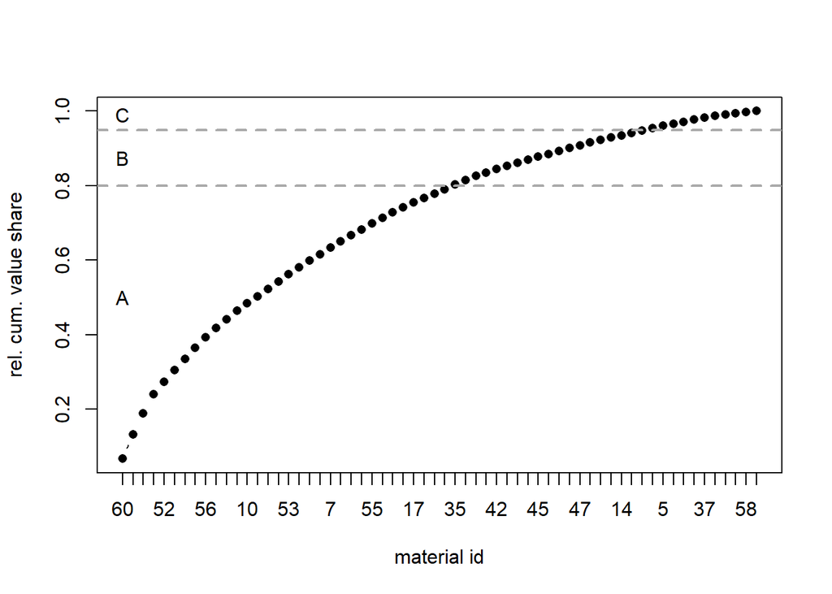

```r
# a plot
plot(1:n, rel.cum.val.vec.ord, type="b", xaxt = "n", pch =16, xlab = "material id", ylab = "rel. cum. value share")
axis(1, at = 1:n, labels = id.vec.ord)
abline(h = c(.8,.95), lwd=2, lty=2, col="darkgrey")
text(x = rep(1,3) , y = c(.5,.875,.99), labels = LETTERS[1:3] )
```

## IQR Analysis

Categorization by life cycle - Inventory quality ratio

Aim is to minimize the risk of obselensce.

- Life cycle of product $i$ is the change of demand over time.
- Variation of material with respect to it’s importance. Typically associated with ABC analysis.
- The higher the value of materials, the potential risk of obscelence situation. This risk increase if this are compared to it’s demand overstocked.

There are 262 days working in consideration, 5 working days in a week, $=52.4 $ that is 52 weeks in a year. So we assume that current stock level is equivelent to stocks that can fit lane assignments for each item and

- $\hat w_i \Rightarrow$ estimated demand value per period (week).
- $s_i \Rightarrow$ The current stock value.
- $o_i \Rightarrow$The accepted turnover time of material $i \in I,$ then.

We will use these thresholds : A…2 per., B..4 per. and C..6 per.

1. Calculate active inventory $to_i = \hat w_i \cdot o_i$
2. Inventory quatlity ratio $IQR_i= \frac {to_i}{s_i}$ the closer to 1, the better.

```r
n <- 62
set.seed(123456)
ave.stock.vec <- floor(stock.level)

o.vec <- as.factor(class.vec)
levels(o.vec) <- c(2,4,6)
o.vec <- as.numeric(as.character(o.vec))
names(o.vec) <- id.vec.ord

s.vec <- product_data$box_cost *ave.stock.vec
#paste("Stock ",s.vec)

toval.vec <- o.vec[as.character(1:n)]*(product_data$deman_per_day_boxes)* product_data$box_cost
#paste("active Inve ",toval.vec)

a.vec <- apply(cbind(s.vec, toval.vec),1 , min)
#a.vec

iqr.vec2 <- toval.vec/s.vec
e.vec <- s.vec - a.vec
#e.vec
e.vec2 <- s.vec - toval.vec
#e.vec2
tab <- data.frame("material.id" = 1:n, "stock.value" = round(s.vec,1), "to.value/act.inv" = round(toval.vec,1),  "iqr" = round(iqr.vec2,1), "excess.inv" = round(e.vec2,1))

kable(tab, digits = c(0,1,1,1,1),  caption = "Life-cycle analysis for materials 1-62", format = "pandoc")
```

Life-cycle analysis for materials 1-62

| material.id | stock.value | to.value.act.inv | iqr | excess.inv |
| --- | --- | --- | --- | --- |
| 1 | 1359.0 | 36.2 | 0.0 | 1322.8 |
| 2 | 3429.0 | 457.2 | 0.1 | 2971.8 |
| 3 | 729.0 | 194.4 | 0.3 | 534.6 |
| 4 | 724.8 | 271.8 | 0.4 | 453.0 |
| 5 | 724.8 | 271.8 | 0.4 | 453.0 |
| 6 | 1456.0 | 546.0 | 0.4 | 910.0 |
| 7 | 1001.7 | 667.8 | 0.7 | 333.9 |
| 8 | 257.4 | 514.8 | 2.0 | -257.4 |
| 9 | 3645.0 | 243.0 | 0.1 | 3402.0 |
| 10 | 2304.0 | 153.6 | 0.1 | 2150.4 |
| 11 | 900.0 | 180.0 | 0.2 | 720.0 |
| 12 | 727.2 | 242.4 | 0.3 | 484.8 |
| 13 | 1537.2 | 256.2 | 0.2 | 1281.0 |
| 14 | 729.6 | 364.8 | 0.5 | 364.8 |
| 15 | 661.5 | 378.0 | 0.6 | 283.5 |
| 16 | 2275.2 | 189.6 | 0.1 | 2085.6 |
| 17 | 747.0 | 39.8 | 0.1 | 707.2 |
| 18 | 704.2 | 37.6 | 0.1 | 666.7 |
| 19 | 1108.8 | 73.9 | 0.1 | 1034.9 |
| 20 | 660.0 | 36.0 | 0.1 | 624.0 |
| 21 | 1386.0 | 37.8 | 0.0 | 1348.2 |
| 22 | 941.2 | 43.4 | 0.0 | 897.8 |
| 23 | 553.8 | 51.1 | 0.1 | 502.7 |
| 24 | 489.6 | 36.7 | 0.1 | 452.9 |
| 25 | 544.0 | 40.8 | 0.1 | 503.2 |
| 26 | 407.7 | 54.4 | 0.1 | 353.3 |
| 27 | 1787.4 | 79.4 | 0.0 | 1708.0 |
| 28 | 639.0 | 255.6 | 0.4 | 383.4 |
| 29 | 645.0 | 258.0 | 0.4 | 387.0 |
| 30 | 740.0 | 44.4 | 0.1 | 695.6 |
| 31 | 648.0 | 38.9 | 0.1 | 609.1 |
| 32 | 1518.0 | 30.4 | 0.0 | 1487.6 |
| 33 | 1266.0 | 25.3 | 0.0 | 1240.7 |
| 34 | 1528.0 | 45.8 | 0.0 | 1482.2 |
| 35 | 912.0 | 54.7 | 0.1 | 857.3 |
| 36 | 5565.6 | 1167.6 | 0.2 | 4398.0 |
| 37 | 451.9 | 284.4 | 0.6 | 167.5 |
| 38 | 451.2 | 507.6 | 1.1 | -56.4 |
| 39 | 2044.8 | 68.2 | 0.0 | 1976.6 |
| 40 | 3481.2 | 116.0 | 0.0 | 3365.2 |
| 41 | 630.0 | 315.0 | 0.5 | 315.0 |
| 42 | 1065.6 | 355.2 | 0.3 | 710.4 |
| 43 | 411.4 | 336.6 | 0.8 | 74.8 |
| 44 | 604.8 | 201.6 | 0.3 | 403.2 |
| 45 | 608.4 | 202.8 | 0.3 | 405.6 |
| 46 | 598.4 | 224.4 | 0.4 | 374.0 |
| 47 | 563.2 | 211.2 | 0.4 | 352.0 |
| 48 | 258.8 | 621.0 | 2.4 | -362.2 |
| 49 | 117.8 | 282.6 | 2.4 | -164.9 |
| 50 | 3235.2 | 404.4 | 0.1 | 2830.8 |
| 51 | 1881.6 | 117.6 | 0.1 | 1764.0 |
| 52 | 2547.2 | 1432.8 | 0.6 | 1114.4 |
| 53 | 1470.0 | 294.0 | 0.2 | 1176.0 |
| 54 | 928.8 | 154.8 | 0.2 | 774.0 |
| 55 | 1202.4 | 100.2 | 0.1 | 1102.2 |
| 56 | 2217.6 | 184.8 | 0.1 | 2032.8 |
| 57 | 2948.4 | 1179.4 | 0.4 | 1769.0 |
| 58 | 192.0 | 230.4 | 1.2 | -38.4 |
| 59 | 2106.7 | 191.5 | 0.1 | 1915.2 |
| 60 | 5649.6 | 513.6 | 0.1 | 5136.0 |
| 61 | 1756.0 | 210.7 | 0.1 | 1545.3 |
| 62 | 1756.0 | 210.7 | 0.1 | 1545.3 |

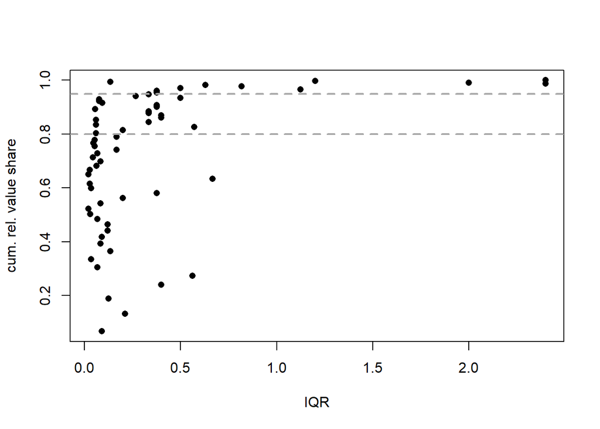

```r
names(iqr.vec2) <- 1:n

names(rel.cum.val.vec.ord)<- id.vec.ord

{plot(iqr.vec2 , rel.cum.val.vec.ord[as.character(1:n)] , xlab="IQR", pch=16, ylab="cum. rel. value share")
abline(h=c(.8, .95), lty=2, lwd=2, col="darkgrey")
text(x = c(60,rep(100,3)) , y = c(0.2,.5,.875,.99), labels = c("fast mover", LETTERS[1:3]) )}
```

## Cost Analysis

```r
#with no constraint
##paste("Seperate Ordering with no capacity constraint, cost is  €", round(obj.fun(product_data$eoq.max)))#172280

#with no capacity constraint optimized.
#paste("Seperate Ordering with no capacity constraint optimized, cost is  €",round(obj.fun(copt_sol1$solution)))# eoq.min

#with constraint
##paste("Seperate Ordering with capacity constraint, cost is  €",round(obj.fun(copt_sol$solution))) #202280

#JRP

##paste("Joint Ordering with no capacity constraint, cost is  €",round(c.cost.int)," for m")# € 49943


##paste("Joint Ordering with no capacity constraint, cost is  €",round(copt_sol2$objval)," for T")# € 49943


##paste("Joint Ordering with capacity constraint, cost is  €",round(copt_sol3$objval)," for m")# € 49943


cost.matrix <- data.frame("unconstrained"=c(round(obj.fun(product_data$eoq.max)),round(c.cost.int)),
                      "constrained"=c(round(obj.fun(copt_sol$solution)),round(copt_sol3$objval)))
rownames(cost.matrix)=c("Separate Ordering","Joint Ordering")

kable(cost.matrix,digits = c(0,1,1,1),caption = "Total cost Matrix", row.names = T, escape = F,format = "pandoc")
```

Total cost Matrix

|  | unconstrained | constrained |
| --- | --- | --- |
| Separate Ordering | 174363 | 206266 |
| Joint Ordering | 49943 | 268254 |

in the matrix above, it costs more to When capacity is an issue for both seperate Ordering and Joint Ordering. When non capacited ordering, there is far more cost savings than Separate ordering.

```r
#?seq.int
#Seperate ordering sequence

so.mat<- matrix(0,nrow = 62, ncol = 40)

for (i in 1:62) {

  so.mat[i,]<- seq.int(round(product_data$eoq.max[i]),round(copt_sol$solution[i]) ,length.out = 40)

}

#JRP
# lower cost
#q.vec

quant.no.const <- data.frame(rbind(round(q.vec )))
colnames(quant.no.const) <- reo.id
rownames(quant.no.const) <- c("$q_i$")
kable(quant.no.const[,1:10],"pandoc", row.names = T)
```

[output not shown]

```r
library(gtools)
quant.no.const<-quant.no.const[mixedorder(colnames(quant.no.const))]
#quant.no.const
# higher cost arranged
#q.start

length(which((quant.no.const > q.start)== TRUE))# 61
```

```
## [1] 62
```

```r
which((quant.no.const < q.start)== TRUE)# only 57
```

```
## integer(0)
```

```r
#quant.no.const[57]

#q.start[57]

so.df <- data.frame(rbind(round(product_data$eoq.max,0),floor(copt_sol$solution)))

so.df <-cbind(sum=c(sum(product_data$eoq.max),sum(copt_sol$solution)),so.df)
rownames(so.df)<- c("Non Constrained","Constrained")

kable(so.df, row.names = T, escape = F,format = "pandoc")
```

[output not shown]

As seen from the table, with no constraint you tend to order far more than constrained.

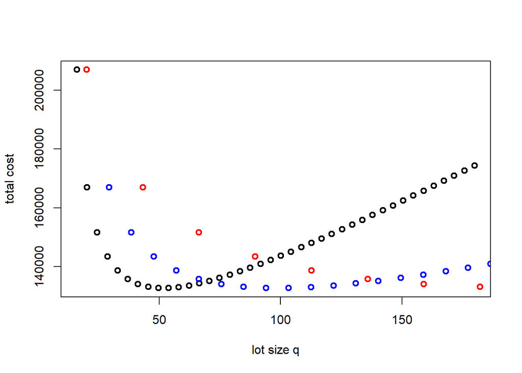

```r
#SO
so.cost.vec <- c(numeric(0),1:40)
for (i in 1:40) {
  so.cost.vec[i] <- obj.fun(so.mat[,i])
}
#so.cost.vec
so.data.mat <- as.data.frame(so.mat)


{plot(x=so.mat[1,], round(so.cost.vec), xlab ="lot size q", ylab = "total cost", type = "p", lwd = 2)
points(x=so.mat[2,], y=round(so.cost.vec), lwd=2, col="blue")
points(x=so.mat[12,], y=round(so.cost.vec), lwd=2, col="red")}
```

```r
#JO
```

```r
jrp.mat<- matrix(0,nrow = 62, ncol = 40)

for (i in 1:62) {

  jrp.mat[i,]<-seq.int(unlist(quant.no.const[i]),unlist(q.start[i]),length.out = 40)

}

jrp.m.mat <- matrix(0,nrow = 62, ncol = 40)

m.mat<- data.frame(rbind(m.vec.int,df2[1,]))
m.mat <-cbind(sum=c(sum(m.vec.int),sum(df2[1,])),m.mat)
rownames(m.mat)<- c("No Constrained","Constrained")


kable(m.mat, row.names = T, escape = F,format = "pandoc")
```

[output not shown]

Since we have limited capacity, we will order frequently and therefore will not take advantage of cost savings we could have gotten if we have larger capacity.